# Economic forecasting using Machine Learning based on Solid Waste data: An Exploration

```python
import pandas as pd
import numpy as np
import matplotlib.pyplot as plt
from sklearn.model_selection import train_test_split
from sklearn.linear_model import LogisticRegression
from sklearn.metrics import f1_score, accuracy_score, confusion_matrix
from sklearn.metrics import mean_squared_error
from sklearn.decomposition import PCA
from sklearn.preprocessing import StandardScaler
from sklearn.linear_model import LinearRegression
from sklearn.tree import DecisionTreeClassifier
from sklearn.tree import DecisionTreeRegressor
from sklearn.svm import SVC
from sklearn.ensemble import RandomForestRegressor
```

## Data Wrangling

### Import Solid Waste Data

```python
durable_raw = pd.read_excel("Materials_Municipal_Waste_Stream_1960_2018.xlsx", sheet_name = "Products generated durable good", index_col = 0)
nondurable_raw = pd.read_excel("Materials_Municipal_Waste_Stream_1960_2018.xlsx", sheet_name = "Products generated nondurable", index_col = 0)
packaging_raw = pd.read_excel("Materials_Municipal_Waste_Stream_1960_2018.xlsx", sheet_name = "Products generated contain&pkg", index_col = 0)
```

#### Solid Waste Data Cleanup

Drop the nondurable and container & packaging values that I will add from another table.

```python
durable = durable_raw.drop(['Products - Nondurable Goods',
                  'Products - Containers and Packaging'])
durable = durable.iloc[:-3] #drop footer rows that don't contain data
durable.index
```

```
Index(['Products - Durable Goods - Major Appliances',
       'Products - Durable Goods - Small Appliances',
       'Products - Durable Goods - Furniture and Furnishings',
       'Products - Durable Goods - Carpets and Rugs',
       'Products - Durable Goods - Rubber Tires',
       'Products - Durable Goods - Batteries, Lead-Acid',
       'Products - Durable Goods - Miscellaneous Durables - Selected Consumer Electronics',
       'Products - Durable Goods - Miscellaneous Durables - Other Miscellaneous Durables',
       'Products - Durable Goods - Miscellaneous Durables -- Total',
       'Products - Durable Goods - Total', 'Products - Wastes - Total',
       'Other Wastes - Food Waste', 'Other Wastes - Yard Trimmings',
       'Other Wastes - Miscellaneous Inorganic Wastes', 'Other Wastes - Total',
       'Total MSW Generated - Weight'],
      dtype='object', name='Products')
```

```python
nondurable = nondurable_raw.drop(['Products - Durable Goods', 'Products – Containers and Packaging', 'Products – Nondurable goods - Directories',
                                  'Products – Wastes –Total', 'Other Wastes -- Total', 'Total MSW Generated – Weight  '])
nondurable = nondurable.iloc[:-3] #drop footer rows that don't contain data
nondurable.index
```

```
Index(['Products - Nondurable goods – Newspapers/Mechanical Papers',
       'Products – Nondurable goods – Other paper nondurable goods – books and magazines',
       'Products – Nondurable goods – Other paper nondurable goods – books',
       'Products – Nondurable goods – Other paper nondurable goods – magazines',
       'Products -  Nondurable goods – Other paper nondurable goods – office-type papers',
       'Products -  Nondurable goods – Other paper nondurable goods – marketing mail',
       'Products – Nondurable goods – Other paper nondurable goods – other commercial printing',
       'Products – Nondurable goods – Other paper nondurable goods – tissue paper and towels',
       'Products – Nondurable goods – Other paper nondurable goods – paper plates and cups',
       'Products – Nondurable goods – Other paper nondurable goods – other nonpackaging paper',
       'Products – Nondurable goods – Other paper nondurable goods – Total',
       'Products – Nondurable goods – Disposable Diapers',
       'Products – Nondurable goods – Plastic Plates and Cups',
       'Products – Nondurable goods – Trash Bags',
       'Products – Nondurable goods – Clothing and Footwear',
       'Products – Nondurable goods – Towels, Sheets and Pillowcases',
       'Products – Nondurable goods – Other Miscellaneous Nondurables',
       'Products – Nondurable goods – Total'],
      dtype='object', name='Products')
```

```python
packaging = packaging_raw.drop(['Products – Durable goods', 'Products – Nondurable goods',
                               'Products – Containers and Packaging – Paper & Paperboard Pkg – Other Paper & Paperboard Pkg – Wrapping Papers'])
packaging = packaging.iloc[:-9] #drop footer rows and the last 6 rows that repeat data from the above tables
packaging.index
```

```
Index(['Products – Containers and Packaging – Glass Packaging – Beer and Soft Drink Bottles',
       'Products – Containers and Packaging – Glass Packaging – Wine and Liquor Bottles',
       'Products – Containers and Packaging – Glass Packaging – Other Bottles and Jars',
       'Products – Containers and Packaging – Glass Packaging – Total',
       'Products – Containers and Packaging – Steel Packaging – Beer and Soft Drink Cans',
       'Products – Containers and Packaging – Steel Packaging – Cans',
       'Products – Containers and Packaging – Steel Packaging – Other Steel Packaging',
       'Products – Containers and Packaging – Steel Packaging – Total',
       'Products – Containers and Packaging – Aluminum Packaging – Beer and Soft Drink Cans',
       'Products – Containers and Packaging – Aluminum Packaging – Other Cans',
       'Products – Containers and Packaging – Aluminum Packaging – Foil and closures',
       'Products – Containers and Packaging—Aluminum Packaging – Total',
       'Products – Containers and Packaging – Paper & Paperboard Pkg – Corrugated Boxes',
       'Products – Containers and Packaging – Paper & Paperboard Pkg – Other Paper & Paperboard Pkg-Gable Top/Aseptic Cartons',
       'Products – Containers and Packaging – Paper & Paperboard Pkg – Other Paper & Paperboard Pkg- Folding Cartons',
       'Products – Containers and Packaging – Paper & Paperboard Pkg – Other Paper & Paperboard Pkg- Other Paperboard Packaging',
       'Products – Containers and Packaging – Paper & Paperboard Pkg – Other Paper & Paperboard Pkg – Bags and Sacks',
       'Products – Containers and Packaging – Paper & Paperboard Pkg – Other Paper & Paperboard Pkg – Other Paper Packaging',
       'Products – Containers and Packaging – Paper & Paperboard Pkg – Other Paper & Paperboard Pkg -- Subtotal',
       'Products – Containers and Packaging – Paper & Paperboard Pkg -- Total',
       'Products – Containers and Packaging – Plastics Packaging – PET Bottles and Jars',
       'Products – Containers and Packaging – Plastics Packaging – HDPE Natural Bottles',
       'Products – Containers and Packaging – Plastics Packaging – Other Containers',
       'Products – Containers and Packaging – Plastics Packaging – Bags, Sacks, and Wraps -- Subtotal',
       'Products – Containers and Packaging – Plastics Packaging – Other Plastics Packaging',
       'Products – Containers and Packaging – Plastics Packaging -- Total',
       'Products – Containers and Packaging – Wood Packaging',
       'Products – Containers and Packaging – Other Miscellaneous Packaging',
       'Products - Containers and Packaging - Total'],
      dtype='object', name='Products')
```

```python
garbage = pd.concat([durable, nondurable, packaging])
```

```python
garbage = garbage.transpose()
```

#### Deal with missing data:

Missing data is represented as 0s in my df.

```python
rowsWithZeros = (garbage == 0).any(axis=1)
garbage[rowsWithZeros]
```

| Products | Products - Durable Goods - Major Appliances | Products - Durable Goods - Small Appliances | Products - Durable Goods - Furniture and Furnishings | Products - Durable Goods - Carpets and Rugs | Products - Durable Goods - Rubber Tires | Products - Durable Goods - Batteries, Lead-Acid | Products - Durable Goods - Miscellaneous Durables - Selected Consumer Electronics | Products - Durable Goods - Miscellaneous Durables - Other Miscellaneous Durables | Products - Durable Goods - Miscellaneous Durables -- Total | Products - Durable Goods - Total | ... | Products – Containers and Packaging – Paper & Paperboard Pkg -- Total | Products – Containers and Packaging – Plastics Packaging – PET Bottles and Jars | Products – Containers and Packaging – Plastics Packaging – HDPE Natural Bottles | Products – Containers and Packaging – Plastics Packaging – Other Containers | Products – Containers and Packaging – Plastics Packaging – Bags, Sacks, and Wraps -- Subtotal | Products – Containers and Packaging – Plastics Packaging – Other Plastics Packaging | Products – Containers and Packaging – Plastics Packaging -- Total | Products – Containers and Packaging – Wood Packaging | Products – Containers and Packaging – Other Miscellaneous Packaging | Products - Containers and Packaging - Total |
| --- | --- | --- | --- | --- | --- | --- | --- | --- | --- | --- | --- | --- | --- | --- | --- | --- | --- | --- | --- | --- | --- |
| 1960 | 1630000.0 | 0.0 | 2150000.0 | 0.0 | 1120000.0 | 0.0 | 0.0 | 0.0 | 5020000.0 | 9920000.0 | ... | 14110000.0 | 0.0 | 0.0 | 60000.0 | 0.0 | 60000.0 | 120000.0 | 2000000.0 | 120000.0 | 27370000.0 |
| 1970 | 2170000.0 | 0.0 | 2830000.0 | 0.0 | 1890000.0 | 820000.0 | 0.0 | 0.0 | 6950000.0 | 14660000.0 | ... | 21400000.0 | 0.0 | 0.0 | 910000.0 | 0.0 | 1180000.0 | 2090000.0 | 2070000.0 | 130000.0 | 43560000.0 |
| 1980 | 2950000.0 | 0.0 | 4760000.0 | 0.0 | 2720000.0 | 1490000.0 | 0.0 | 0.0 | 9880000.0 | 21800000.0 | ... | 26350000.0 | 260000.0 | 230000.0 | 890000.0 | 1230000.0 | 790000.0 | 3400000.0 | 3940000.0 | 130000.0 | 52670000.0 |
| 1990 | 3310000.0 | 460000.0 | 6790000.0 | 1660000.0 | 3610000.0 | 1510000.0 | 0.0 | 0.0 | 12470000.0 | 29810000.0 | ... | 32680000.0 | 430000.0 | 530000.0 | 1430000.0 | 2470000.0 | 2040000.0 | 6900000.0 | 8180000.0 | 150000.0 | 64530000.0 |
| 2000 | 3640000.0 | 1040000.0 | 8120000.0 | 2460000.0 | 4930000.0 | 2280000.0 | 1900000.0 | 14500000.0 | 16400000.0 | 38870000.0 | ... | 39940000.0 | 1720000.0 | 690000.0 | 1740000.0 | 4200000.0 | 2840000.0 | 11190000.0 | 8610000.0 | 240000.0 | 75840000.0 |
| 2005 | 3610000.0 | 1180000.0 | 9340000.0 | 2960000.0 | 4910000.0 | 2750000.0 | 2630000.0 | 17680000.0 | 20310000.0 | 45060000.0 | ... | 39640000.0 | 2540000.0 | 800000.0 | 1420000.0 | 4450000.0 | 3210000.0 | 12420000.0 | 9230000.0 | 280000.0 | 76330000.0 |
| 2010 | 4020000.0 | 1830000.0 | 10820000.0 | 3720000.0 | 5130000.0 | 3020000.0 | 3120000.0 | 17690000.0 | 20810000.0 | 49350000.0 | ... | 37680000.0 | 2670000.0 | 800000.0 | 1830000.0 | 3930000.0 | 4450000.0 | 13680000.0 | 9770000.0 | 340000.0 | 75470000.0 |
| 2011 | 4080000.0 | 1900000.0 | 11130000.0 | 3830000.0 | 5390000.0 | 3000000.0 | 3210000.0 | 17830000.0 | 21040000.0 | 50370000.0 | ... | 38020000.0 | 2740000.0 | 770000.0 | 1870000.0 | 3880000.0 | 4640000.0 | 13900000.0 | 9700000.0 | 350000.0 | 75340000.0 |
| 2012 | 4190000.0 | 1950000.0 | 11500000.0 | 3860000.0 | 5540000.0 | 2890000.0 | 3310000.0 | 17650000.0 | 20960000.0 | 50890000.0 | ... | 38010000.0 | 2790000.0 | 780000.0 | 1850000.0 | 3810000.0 | 4550000.0 | 13780000.0 | 9610000.0 | 350000.0 | 75230000.0 |
| 2013 | 4470000.0 | 1960000.0 | 11620000.0 | 3820000.0 | 5760000.0 | 2840000.0 | 3360000.0 | 18680000.0 | 22040000.0 | 52510000.0 | ... | 38560000.0 | 2880000.0 | 780000.0 | 1830000.0 | 3780000.0 | 4710000.0 | 13980000.0 | 9410000.0 | 360000.0 | 75770000.0 |
| 2014 | 4650000.0 | 2010000.0 | 11860000.0 | 3730000.0 | 5560000.0 | 2810000.0 | 3360000.0 | 18690000.0 | 22050000.0 | 52670000.0 | ... | 39130000.0 | 2920000.0 | 780000.0 | 1850000.0 | 4050000.0 | 4720000.0 | 14320000.0 | 9680000.0 | 360000.0 | 76860000.0 |
| 2015 | 4860000.0 | 2050000.0 | 12050000.0 | 3630000.0 | 5970000.0 | 2700000.0 | 3100000.0 | 19580000.0 | 22680000.0 | 53940000.0 | ... | 39920000.0 | 2980000.0 | 760000.0 | 1940000.0 | 4130000.0 | 4870000.0 | 14680000.0 | 9770000.0 | 370000.0 | 77920000.0 |
| 2016 | 5030000.0 | 2090000.0 | 12210000.0 | 3510000.0 | 6830000.0 | 2650000.0 | 2990000.0 | 20550000.0 | 23540000.0 | 55860000.0 | ... | 39990000.0 | 3080000.0 | 770000.0 | 1970000.0 | 4090000.0 | 4600000.0 | 14510000.0 | 11840000.0 | 350000.0 | 80950000.0 |
| 2017 | 5160000.0 | 2120000.0 | 12210000.0 | 3390000.0 | 6540000.0 | 2940000.0 | 2840000.0 | 21670000.0 | 24510000.0 | 56870000.0 | ... | 41060000.0 | 2960000.0 | 770000.0 | 1990000.0 | 4140000.0 | 4630000.0 | 14490000.0 | 11560000.0 | 350000.0 | 81200000.0 |
| 2018 | 5250000.0 | 2160000.0 | 12080000.0 | 3370000.0 | 6530000.0 | 2900000.0 | 2700000.0 | 22110000.0 | 24810000.0 | 57100000.0 | ... | 41900000.0 | 3130000.0 | 750000.0 | 1990000.0 | 4200000.0 | 4460000.0 | 14530000.0 | 11530000.0 | 340000.0 | 82220000.0 |

15 rows × 63 columns

The category Products - Durable Goods - Small Appliances appears to not have been used for the first three decades of my data. The appliance columns of the durable goods I think may be important (have correlation with recession indicators). I'd like to impute this data based on the trend set by the other values. Should I use all the later values to plot the trend? The graph below would seem to indicate that in order to continue with the same trend, I should use the trend line from 1990 to 2010, since the regression line afterward is markedly different.

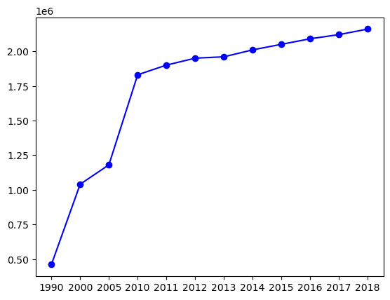

```python
x = pd.Series(garbage.index)
x = x.iloc[3:]
xstr = x.astype(str)
y = garbage['Products - Durable Goods - Small Appliances'].iloc[3:]
plt.plot(xstr, y, marker='o', linestyle='-', color='b')
plt.show()
```

```python
years = pd.Series(garbage.index).iloc[3:7] #these are the years over which to take trend (1990 - 2010)
values = garbage['Products - Durable Goods - Small Appliances'].iloc[3:7].values
years_reshaped = years.values.reshape(-1, 1) #to run regression, my X has to be 2D
lr = LinearRegression()
lr.fit(years_reshaped, values)
#now use lr to predict first 3 values
missing_years = pd.Series(garbage.index).iloc[:3]
missing_years_reshaped = missing_years.values.reshape(-1,1)
predicted_values = lr.predict(missing_years_reshaped)
garbage_clean = garbage.copy()
garbage_clean.loc[garbage_clean.index[:3], 'Products - Durable Goods - Small Appliances'] = predicted_values
```

```python
garbage_clean.iloc[:3]
```

| Products | Products - Durable Goods - Major Appliances | Products - Durable Goods - Small Appliances | Products - Durable Goods - Furniture and Furnishings | Products - Durable Goods - Carpets and Rugs | Products - Durable Goods - Rubber Tires | Products - Durable Goods - Batteries, Lead-Acid | Products - Durable Goods - Miscellaneous Durables - Selected Consumer Electronics | Products - Durable Goods - Miscellaneous Durables - Other Miscellaneous Durables | Products - Durable Goods - Miscellaneous Durables -- Total | Products - Durable Goods - Total | ... | Products – Containers and Packaging – Paper & Paperboard Pkg -- Total | Products – Containers and Packaging – Plastics Packaging – PET Bottles and Jars | Products – Containers and Packaging – Plastics Packaging – HDPE Natural Bottles | Products – Containers and Packaging – Plastics Packaging – Other Containers | Products – Containers and Packaging – Plastics Packaging – Bags, Sacks, and Wraps -- Subtotal | Products – Containers and Packaging – Plastics Packaging – Other Plastics Packaging | Products – Containers and Packaging – Plastics Packaging -- Total | Products – Containers and Packaging – Wood Packaging | Products – Containers and Packaging – Other Miscellaneous Packaging | Products - Containers and Packaging - Total |
| --- | --- | --- | --- | --- | --- | --- | --- | --- | --- | --- | --- | --- | --- | --- | --- | --- | --- | --- | --- | --- | --- |
| 1960 | 1630000.0 | -1.505429e+06 | 2150000.0 | 0.0 | 1120000.0 | 0.0 | 0.0 | 0.0 | 5020000.0 | 9920000.0 | ... | 14110000.0 | 0.0 | 0.0 | 60000.0 | 0.0 | 60000.0 | 120000.0 | 2000000.0 | 120000.0 | 27370000.0 |
| 1970 | 2170000.0 | -8.671429e+05 | 2830000.0 | 0.0 | 1890000.0 | 820000.0 | 0.0 | 0.0 | 6950000.0 | 14660000.0 | ... | 21400000.0 | 0.0 | 0.0 | 910000.0 | 0.0 | 1180000.0 | 2090000.0 | 2070000.0 | 130000.0 | 43560000.0 |
| 1980 | 2950000.0 | -2.288571e+05 | 4760000.0 | 0.0 | 2720000.0 | 1490000.0 | 0.0 | 0.0 | 9880000.0 | 21800000.0 | ... | 26350000.0 | 260000.0 | 230000.0 | 890000.0 | 1230000.0 | 790000.0 | 3400000.0 | 3940000.0 | 130000.0 | 52670000.0 |

3 rows × 63 columns

That didn't work. The regression line took my Small Appliances estimates into the negative. It makes sense why it did this. Honestly, before this situation, I hadn't considered using regression for imputing missing values but in other circumstances, it would makes sense especially with time series. Check one more thing: what if I created my trend line over all my time periods, it should have a less steep slope.

```python
years = pd.Series(garbage.index).iloc[3:]
values = garbage['Products - Durable Goods - Small Appliances'].iloc[3:]
years_reshaped = years.values.reshape(-1, 1) #to run regression, my X has to be 2D
lr = LinearRegression()
lr.fit(years_reshaped, values)
#now use lr to predict first 3 values
missing_years = pd.Series(garbage.index).iloc[:3]
missing_years_reshaped = missing_years.values.reshape(-1,1)
predicted_values = lr.predict(missing_years_reshaped)
garbage_clean = garbage.copy()
garbage_clean.loc[garbage_clean.index[:3], 'Products - Durable Goods - Small Appliances'] = predicted_values
```

```python
garbage_clean.iloc[:3]
```

| Products | Products - Durable Goods - Major Appliances | Products - Durable Goods - Small Appliances | Products - Durable Goods - Furniture and Furnishings | Products - Durable Goods - Carpets and Rugs | Products - Durable Goods - Rubber Tires | Products - Durable Goods - Batteries, Lead-Acid | Products - Durable Goods - Miscellaneous Durables - Selected Consumer Electronics | Products - Durable Goods - Miscellaneous Durables - Other Miscellaneous Durables | Products - Durable Goods - Miscellaneous Durables -- Total | Products - Durable Goods - Total | ... | Products – Containers and Packaging – Paper & Paperboard Pkg -- Total | Products – Containers and Packaging – Plastics Packaging – PET Bottles and Jars | Products – Containers and Packaging – Plastics Packaging – HDPE Natural Bottles | Products – Containers and Packaging – Plastics Packaging – Other Containers | Products – Containers and Packaging – Plastics Packaging – Bags, Sacks, and Wraps -- Subtotal | Products – Containers and Packaging – Plastics Packaging – Other Plastics Packaging | Products – Containers and Packaging – Plastics Packaging -- Total | Products – Containers and Packaging – Wood Packaging | Products – Containers and Packaging – Other Miscellaneous Packaging | Products - Containers and Packaging - Total |
| --- | --- | --- | --- | --- | --- | --- | --- | --- | --- | --- | --- | --- | --- | --- | --- | --- | --- | --- | --- | --- | --- |
| 1960 | 1630000.0 | -1.527710e+06 | 2150000.0 | 0.0 | 1120000.0 | 0.0 | 0.0 | 0.0 | 5020000.0 | 9920000.0 | ... | 14110000.0 | 0.0 | 0.0 | 60000.0 | 0.0 | 60000.0 | 120000.0 | 2000000.0 | 120000.0 | 27370000.0 |
| 1970 | 2170000.0 | -8.774185e+05 | 2830000.0 | 0.0 | 1890000.0 | 820000.0 | 0.0 | 0.0 | 6950000.0 | 14660000.0 | ... | 21400000.0 | 0.0 | 0.0 | 910000.0 | 0.0 | 1180000.0 | 2090000.0 | 2070000.0 | 130000.0 | 43560000.0 |
| 1980 | 2950000.0 | -2.271270e+05 | 4760000.0 | 0.0 | 2720000.0 | 1490000.0 | 0.0 | 0.0 | 9880000.0 | 21800000.0 | ... | 26350000.0 | 260000.0 | 230000.0 | 890000.0 | 1230000.0 | 790000.0 | 3400000.0 | 3940000.0 | 130000.0 | 52670000.0 |

3 rows × 63 columns

The trend line method of imputing these values isn't working. I'll choose to backfill with the most recent value.

```python
garbage_clean = garbage.copy()
earliest_value = garbage_clean['Products - Durable Goods - Small Appliances'].iloc[3]
garbage_clean['Products - Durable Goods - Small Appliances'] = garbage_clean['Products - Durable Goods - Small Appliances'].replace(0, earliest_value)
garbage_clean[garbage_clean['Products - Durable Goods - Small Appliances'] == earliest_value]
```

| Products | Products - Durable Goods - Major Appliances | Products - Durable Goods - Small Appliances | Products - Durable Goods - Furniture and Furnishings | Products - Durable Goods - Carpets and Rugs | Products - Durable Goods - Rubber Tires | Products - Durable Goods - Batteries, Lead-Acid | Products - Durable Goods - Miscellaneous Durables - Selected Consumer Electronics | Products - Durable Goods - Miscellaneous Durables - Other Miscellaneous Durables | Products - Durable Goods - Miscellaneous Durables -- Total | Products - Durable Goods - Total | ... | Products – Containers and Packaging – Paper & Paperboard Pkg -- Total | Products – Containers and Packaging – Plastics Packaging – PET Bottles and Jars | Products – Containers and Packaging – Plastics Packaging – HDPE Natural Bottles | Products – Containers and Packaging – Plastics Packaging – Other Containers | Products – Containers and Packaging – Plastics Packaging – Bags, Sacks, and Wraps -- Subtotal | Products – Containers and Packaging – Plastics Packaging – Other Plastics Packaging | Products – Containers and Packaging – Plastics Packaging -- Total | Products – Containers and Packaging – Wood Packaging | Products – Containers and Packaging – Other Miscellaneous Packaging | Products - Containers and Packaging - Total |
| --- | --- | --- | --- | --- | --- | --- | --- | --- | --- | --- | --- | --- | --- | --- | --- | --- | --- | --- | --- | --- | --- |
| 1960 | 1630000.0 | 460000.0 | 2150000.0 | 0.0 | 1120000.0 | 0.0 | 0.0 | 0.0 | 5020000.0 | 9920000.0 | ... | 14110000.0 | 0.0 | 0.0 | 60000.0 | 0.0 | 60000.0 | 120000.0 | 2000000.0 | 120000.0 | 27370000.0 |
| 1970 | 2170000.0 | 460000.0 | 2830000.0 | 0.0 | 1890000.0 | 820000.0 | 0.0 | 0.0 | 6950000.0 | 14660000.0 | ... | 21400000.0 | 0.0 | 0.0 | 910000.0 | 0.0 | 1180000.0 | 2090000.0 | 2070000.0 | 130000.0 | 43560000.0 |
| 1980 | 2950000.0 | 460000.0 | 4760000.0 | 0.0 | 2720000.0 | 1490000.0 | 0.0 | 0.0 | 9880000.0 | 21800000.0 | ... | 26350000.0 | 260000.0 | 230000.0 | 890000.0 | 1230000.0 | 790000.0 | 3400000.0 | 3940000.0 | 130000.0 | 52670000.0 |
| 1990 | 3310000.0 | 460000.0 | 6790000.0 | 1660000.0 | 3610000.0 | 1510000.0 | 0.0 | 0.0 | 12470000.0 | 29810000.0 | ... | 32680000.0 | 430000.0 | 530000.0 | 1430000.0 | 2470000.0 | 2040000.0 | 6900000.0 | 8180000.0 | 150000.0 | 64530000.0 |

4 rows × 63 columns

The initial decade data is missing a fair amount of data. I'd like to try and see if the trend method for imputation will work for any of these. To make this quicker, I'll set up my trend line prediction in a function.

```python
def predict_by_trend(column_name, numVals):
    years = pd.Series(garbage.index).iloc[numVals:]
    values = garbage[column_name].iloc[numVals:]
    years_reshaped = years.values.reshape(-1, 1) #to run regression, my X has to be 2D
    lr = LinearRegression()
    lr.fit(years_reshaped, values)
    #now use lr to predict first numVals values
    missing_years = pd.Series(garbage.index).iloc[:numVals]
    missing_years_reshaped = missing_years.values.reshape(-1,1)
    predicted_values = lr.predict(missing_years_reshaped)
    return predicted_values
```

```python
garbage_test = garbage.copy()
garbage_test.loc[garbage_test.index[:3], 'Products - Durable Goods - Carpets and Rugs'] = predict_by_trend('Products - Durable Goods - Carpets and Rugs', 3)
garbage_test.iloc[:4]
```

| Products | Products - Durable Goods - Major Appliances | Products - Durable Goods - Small Appliances | Products - Durable Goods - Furniture and Furnishings | Products - Durable Goods - Carpets and Rugs | Products - Durable Goods - Rubber Tires | Products - Durable Goods - Batteries, Lead-Acid | Products - Durable Goods - Miscellaneous Durables - Selected Consumer Electronics | Products - Durable Goods - Miscellaneous Durables - Other Miscellaneous Durables | Products - Durable Goods - Miscellaneous Durables -- Total | Products - Durable Goods - Total | ... | Products – Containers and Packaging – Paper & Paperboard Pkg -- Total | Products – Containers and Packaging – Plastics Packaging – PET Bottles and Jars | Products – Containers and Packaging – Plastics Packaging – HDPE Natural Bottles | Products – Containers and Packaging – Plastics Packaging – Other Containers | Products – Containers and Packaging – Plastics Packaging – Bags, Sacks, and Wraps -- Subtotal | Products – Containers and Packaging – Plastics Packaging – Other Plastics Packaging | Products – Containers and Packaging – Plastics Packaging -- Total | Products – Containers and Packaging – Wood Packaging | Products – Containers and Packaging – Other Miscellaneous Packaging | Products - Containers and Packaging - Total |
| --- | --- | --- | --- | --- | --- | --- | --- | --- | --- | --- | --- | --- | --- | --- | --- | --- | --- | --- | --- | --- | --- |
| 1960 | 1630000.0 | 0.0 | 2150000.0 | -2.377924e+05 | 1120000.0 | 0.0 | 0.0 | 0.0 | 5020000.0 | 9920000.0 | ... | 14110000.0 | 0.0 | 0.0 | 60000.0 | 0.0 | 60000.0 | 120000.0 | 2000000.0 | 120000.0 | 27370000.0 |
| 1970 | 2170000.0 | 0.0 | 2830000.0 | 4.742460e+05 | 1890000.0 | 820000.0 | 0.0 | 0.0 | 6950000.0 | 14660000.0 | ... | 21400000.0 | 0.0 | 0.0 | 910000.0 | 0.0 | 1180000.0 | 2090000.0 | 2070000.0 | 130000.0 | 43560000.0 |
| 1980 | 2950000.0 | 0.0 | 4760000.0 | 1.186284e+06 | 2720000.0 | 1490000.0 | 0.0 | 0.0 | 9880000.0 | 21800000.0 | ... | 26350000.0 | 260000.0 | 230000.0 | 890000.0 | 1230000.0 | 790000.0 | 3400000.0 | 3940000.0 | 130000.0 | 52670000.0 |
| 1990 | 3310000.0 | 460000.0 | 6790000.0 | 1.660000e+06 | 3610000.0 | 1510000.0 | 0.0 | 0.0 | 12470000.0 | 29810000.0 | ... | 32680000.0 | 430000.0 | 530000.0 | 1430000.0 | 2470000.0 | 2040000.0 | 6900000.0 | 8180000.0 | 150000.0 | 64530000.0 |

4 rows × 63 columns

Based on this initial look at the data, I think this is my idea for imputation: Fill data in using the trend line. Replace any negative values with the next non-negative value in the column. This seems to make the most sense for this data in this time series.

```python
def replace_negatives (df, col_name):
    for i in range (0, len(df[col_name])):
        if (df[col_name].iloc[i] < 0):
            #find next positive value in the column
            next_positive_value = next((val for val in df[col_name][i:] if val > 0), None)
            if (next_positive_value is not None):
                df[col_name].iloc[i] = next_positive_value
```

```python
replace_negatives(garbage_test, 'Products - Durable Goods - Carpets and Rugs')
garbage_test.iloc[:4]
```

| Products | Products - Durable Goods - Major Appliances | Products - Durable Goods - Small Appliances | Products - Durable Goods - Furniture and Furnishings | Products - Durable Goods - Carpets and Rugs | Products - Durable Goods - Rubber Tires | Products - Durable Goods - Batteries, Lead-Acid | Products - Durable Goods - Miscellaneous Durables - Selected Consumer Electronics | Products - Durable Goods - Miscellaneous Durables - Other Miscellaneous Durables | Products - Durable Goods - Miscellaneous Durables -- Total | Products - Durable Goods - Total | ... | Products – Containers and Packaging – Paper & Paperboard Pkg -- Total | Products – Containers and Packaging – Plastics Packaging – PET Bottles and Jars | Products – Containers and Packaging – Plastics Packaging – HDPE Natural Bottles | Products – Containers and Packaging – Plastics Packaging – Other Containers | Products – Containers and Packaging – Plastics Packaging – Bags, Sacks, and Wraps -- Subtotal | Products – Containers and Packaging – Plastics Packaging – Other Plastics Packaging | Products – Containers and Packaging – Plastics Packaging -- Total | Products – Containers and Packaging – Wood Packaging | Products – Containers and Packaging – Other Miscellaneous Packaging | Products - Containers and Packaging - Total |
| --- | --- | --- | --- | --- | --- | --- | --- | --- | --- | --- | --- | --- | --- | --- | --- | --- | --- | --- | --- | --- | --- |
| 1960 | 1630000.0 | 0.0 | 2150000.0 | 4.742460e+05 | 1120000.0 | 0.0 | 0.0 | 0.0 | 5020000.0 | 9920000.0 | ... | 14110000.0 | 0.0 | 0.0 | 60000.0 | 0.0 | 60000.0 | 120000.0 | 2000000.0 | 120000.0 | 27370000.0 |
| 1970 | 2170000.0 | 0.0 | 2830000.0 | 4.742460e+05 | 1890000.0 | 820000.0 | 0.0 | 0.0 | 6950000.0 | 14660000.0 | ... | 21400000.0 | 0.0 | 0.0 | 910000.0 | 0.0 | 1180000.0 | 2090000.0 | 2070000.0 | 130000.0 | 43560000.0 |
| 1980 | 2950000.0 | 0.0 | 4760000.0 | 1.186284e+06 | 2720000.0 | 1490000.0 | 0.0 | 0.0 | 9880000.0 | 21800000.0 | ... | 26350000.0 | 260000.0 | 230000.0 | 890000.0 | 1230000.0 | 790000.0 | 3400000.0 | 3940000.0 | 130000.0 | 52670000.0 |
| 1990 | 3310000.0 | 460000.0 | 6790000.0 | 1.660000e+06 | 3610000.0 | 1510000.0 | 0.0 | 0.0 | 12470000.0 | 29810000.0 | ... | 32680000.0 | 430000.0 | 530000.0 | 1430000.0 | 2470000.0 | 2040000.0 | 6900000.0 | 8180000.0 | 150000.0 | 64530000.0 |

4 rows × 63 columns

This appears to be working. Running this on all of my missing data columns...I don't want to do this by hand. I'm going to create a df of all my columns with zeros in the first row:

```python
cols_to_impute = pd.DataFrame({'Column Name': garbage.loc['1960'][garbage.loc['1960'] == 0].index}) #these are the columns with a 0 in the first row
#how many consecutive zeros do they each have at the top of each column?
num_zeros_list = []
for col_name in cols_to_impute['Column Name']:
    num_zeros = 0
    for value in garbage[col_name]:
        if(value == 0):
            num_zeros = num_zeros + 1
        else: #no more consecutive 0s
            break
    num_zeros_list.append(num_zeros)
cols_to_impute["Number Consec Zeros"] = num_zeros_list
```

```python
cols_to_impute
```

|  | Column Name | Number Consec Zeros |
| --- | --- | --- |
| 0 | Products - Durable Goods - Small Appliances | 3 |
| 1 | Products - Durable Goods - Carpets and Rugs | 3 |
| 2 | Products - Durable Goods - Batteries, Lead-Acid | 1 |
| 3 | Products - Durable Goods - Miscellaneous Durables - Selected Consumer Electronics | 4 |
| 4 | Products - Durable Goods - Miscellaneous Durables - Other Miscellaneous Durables | 4 |
| 5 | Products – Nondurable goods – Other paper nondurable goods – books | 3 |
| 6 | Products – Nondurable goods – Other paper nondurable goods – magazines | 3 |
| 7 | Products - Nondurable goods – Other paper nondurable goods – marketing mail | 3 |
| 8 | Products – Nondurable goods – Disposable Diapers | 1 |
| 9 | Products – Nondurable goods – Plastic Plates and Cups | 2 |
| 10 | Products – Nondurable goods – Trash Bags | 3 |
| 11 | Products – Nondurable goods – Towels, Sheets and Pillowcases | 3 |
| 12 | Products – Containers and Packaging – Aluminum Packaging – Beer and Soft Drink Cans | 1 |
| 13 | Products – Containers and Packaging – Aluminum Packaging – Other Cans | 1 |
| 14 | Products – Containers and Packaging – Paper & Paperboard Pkg – Other Paper & Paperboard Pkg-Gable Top/Aseptic Cartons | 2 |
| 15 | Products – Containers and Packaging – Paper & Paperboard Pkg – Other Paper & Paperboard Pkg- Folding Cartons | 2 |
| 16 | Products – Containers and Packaging – Paper & Paperboard Pkg – Other Paper & Paperboard Pkg – Bags and Sacks | 2 |
| 17 | Products – Containers and Packaging – Plastics Packaging – PET Bottles and Jars | 2 |
| 18 | Products – Containers and Packaging – Plastics Packaging – HDPE Natural Bottles | 2 |
| 19 | Products – Containers and Packaging – Plastics Packaging – Bags, Sacks, and Wraps -- Subtotal | 2 |

Now clean the columns listed in this dataframe:

```python
garbage_clean = garbage.copy()
for index, row in cols_to_impute.iterrows():
    column_name = row['Column Name']
    consec_zeros = row['Number Consec Zeros']
    garbage_clean.loc[garbage_clean.index[:consec_zeros], column_name] = predict_by_trend(column_name, consec_zeros)
    replace_negatives(garbage_clean, column_name)
```

Check for other (non-leading) missing data:

```python
garbage_clean[garbage_clean.columns[garbage_clean.eq(0).any()]]
```

| Products | Products – Nondurable goods – Other paper nondurable goods – books and magazines | Products – Containers and Packaging – Steel Packaging – Beer and Soft Drink Cans |
| --- | --- | --- |
| 1960 | 1920000.0 | 640000.0 |
| 1970 | 2470000.0 | 1570000.0 |
| 1980 | 3390000.0 | 520000.0 |
| 1990 | 0.0 | 150000.0 |
| 2000 | 0.0 | 0.0 |
| 2005 | 0.0 | 0.0 |
| 2010 | 0.0 | 0.0 |
| 2011 | 0.0 | 0.0 |
| 2012 | 0.0 | 0.0 |
| 2013 | 0.0 | 0.0 |
| 2014 | 0.0 | 0.0 |
| 2015 | 0.0 | 0.0 |
| 2016 | 0.0 | 0.0 |
| 2017 | 0.0 | 0.0 |
| 2018 | 0.0 | 0.0 |

It appears that these two categories were discontinued. I think I'll drop these columns since they're missing so much data.

```python
garbage_clean = garbage_clean.drop(garbage_clean.columns[garbage_clean.eq(0).any()], axis = 1)
```

### Import Recession Data

```python
recessions_raw = pd.read_excel("BCDC_spreadsheet_for_website.xlsx")
recessions_raw.head()
```

|  | Peak month (Peak Quarter) | Trough month (Trough Quarter) | Unnamed: 2 | Unnamed: 3 | Contraction | Expansion | Cycle | Unnamed: 7 |
| --- | --- | --- | --- | --- | --- | --- | --- | --- |
| 0 | NaN | NaN | Peak month number | Trough month number | Duration, peak to trough | Duration, trough to peak | Duration, trough to trough | Duration, peak to peak |
| 1 | NaN | December 1854 (1854Q4) | NaN | 660 | NaN | NaN | NaN | NaN |
| 2 | June 1857 (1857Q2) | December 1858 (1858Q4) | 690 | 708 | 18 | 30 | 48 | NaN |
| 3 | October 1860 (1860Q3) | June 1861 (1861Q3) | 730 | 738 | 8 | 22 | 30 | 40 |
| 4 | April 1865 (1865Q1) | December 1867 (1868Q1) | 784 | 816 | 32 | 46 | 78 | 54 |

#### Recession Data Cleanup

Drop extra rows

```python
recessions = recessions_raw.iloc[:-8] # drop summary rows
recessions = recessions.iloc[27:] #drop years before 1960
recessions
```

|  | Peak month (Peak Quarter) | Trough month (Trough Quarter) | Unnamed: 2 | Unnamed: 3 | Contraction | Expansion | Cycle | Unnamed: 7 |
| --- | --- | --- | --- | --- | --- | --- | --- | --- |
| 27 | April 1960 (1960Q2) | February 1961 (1961Q1) | 1924 | 1934 | 10 | 24 | 34 | 32 |
| 28 | December 1969 (1969Q4) | November 1970 (1970Q4) | 2040 | 2051 | 11 | 106 | 117 | 116 |
| 29 | November 1973 (1973Q4) | March 1975 (1975Q1) | 2087 | 2103 | 16 | 36 | 52 | 47 |
| 30 | January 1980 (1980Q1) | July 1980 (1980Q3) | 2161 | 2167 | 6 | 58 | 64 | 74 |
| 31 | July 1981 (1981Q3) | November 1982 (1982Q4) | 2179 | 2195 | 16 | 12 | 28 | 18 |
| 32 | July 1990 (1990Q3) | March 1991 (1991Q1) | 2287 | 2295 | 8 | 92 | 100 | 108 |
| 33 | March 2001 (2001Q1) | November 2001 (2001Q4) | 2415 | 2423 | 8 | 120 | 128 | 128 |
| 34 | December 2007 (2007Q4) | June 2009 (2009Q2) | 2496 | 2514 | 18 | 73 | 91 | 81 |

Is it better to overrepresent the recessions? i.e. if there was a single month of the year considered recession, should I count this as a recession year? I will keep the recession data by month. When categorizing a year in the garbage data, I will look ahead 6 months for a 1 year time period (for ex if 1960, I will look from July 1961 to June 1962). If this time period includes any that are flagged as recession months, I will classify it as recession.

Create a start month/year and end month/year for each recession and then generate a list containing a row very every recession month/year.

```python
recessions['Period_start'] = recessions['Peak month  (Peak Quarter)'].str.extract(r'^(.*?)\s*\(')
recessions['Period_end'] = recessions['Trough month (Trough Quarter)'].str.extract(r'^(.*?)\s*\(')
recessions.head()
```

|  | Peak month (Peak Quarter) | Trough month (Trough Quarter) | Unnamed: 2 | Unnamed: 3 | Contraction | Expansion | Cycle | Unnamed: 7 | Period_start | Period_end |
| --- | --- | --- | --- | --- | --- | --- | --- | --- | --- | --- |
| 27 | April 1960 (1960Q2) | February 1961 (1961Q1) | 1924 | 1934 | 10 | 24 | 34 | 32 | April 1960 | February 1961 |
| 28 | December 1969 (1969Q4) | November 1970 (1970Q4) | 2040 | 2051 | 11 | 106 | 117 | 116 | December 1969 | November 1970 |
| 29 | November 1973 (1973Q4) | March 1975 (1975Q1) | 2087 | 2103 | 16 | 36 | 52 | 47 | November 1973 | March 1975 |
| 30 | January 1980 (1980Q1) | July 1980 (1980Q3) | 2161 | 2167 | 6 | 58 | 64 | 74 | January 1980 | July 1980 |
| 31 | July 1981 (1981Q3) | November 1982 (1982Q4) | 2179 | 2195 | 16 | 12 | 28 | 18 | July 1981 | November 1982 |

```python
def generate_month_year_range(row):
    month_range = pd.period_range(start=row['Period_start'], end=row['Period_end'], freq='M')
    return month_range
```

```python
recessionMonths = pd.Series(np.concatenate(recessions.apply(generate_month_year_range, axis=1).values))
recessionMonths
```

```
0      1960-04
1      1960-05
2      1960-06
3      1960-07
4      1960-08
5      1960-09
6      1960-10
7      1960-11
8      1960-12
9      1961-01
10     1961-02
11     1969-12
12     1970-01
13     1970-02
14     1970-03
```

[output cut: 87 more lines]

```python
def assignEconomicForecast(row):
    truth = 0 #stands for growth (default)
    ##STOPPED WHEN I DISCOVERED ALL OF MY MISSING YEARS
```

### Import US Population Data

```python
population_raw = pd.read_excel("PopulationData.xlsx")
population_raw.head()
```

|  | Date | Value |
| --- | --- | --- |
| 0 | 2023-07-01 | 334.99 million |
| 1 | 2022-07-01 | 333.29 million |
| 2 | 2021-07-01 | 332.03 million |
| 3 | 2020-07-01 | 331.51 million |
| 4 | 2019-07-01 | 328.24 million |

#### Population Data Cleanup

How did my data import? (What datatypes - this will determine how I need to clean up the data)

```python
population_raw.info()
```

```
<class 'pandas.core.frame.DataFrame'>
RangeIndex: 124 entries, 0 to 123
Data columns (total 2 columns):
 #   Column  Non-Null Count  Dtype
---  ------  --------------  -----
 0   Date    124 non-null    datetime64[ns]
 1   Value   124 non-null    object
dtypes: datetime64[ns](1), object(1)
memory usage: 2.1+ KB
```

The date imported as a datetime object which is perfect. My Value is a string - I will need to manipulate this to get a numeric value for my population.

```python
population = population_raw.copy()
population['Value'].replace(regex = {r' million': ''}, inplace = True)  #strip out the word million
population['Value'] = pd.to_numeric(population['Value']) #cast to float
population['Value'] = population['Value'] * 1000000 #multiply by 1 million to get actual population value
```

My solid waste data is only for the years 1960 through 2018, so I only need these years in the population data.

```python
population = population[(population['Date'].dt.year >= 1960) & (population['Date'].dt.year <= 2018)]
population['Date'] = population['Date'].dt.year
population.set_index('Date', inplace = True) #makes my date easier to use
population.head()
```

| Date | Value |
| --- | --- |
| 2018 | 326690000.0 |
| 2017 | 324990000.0 |
| 2016 | 322940000.0 |
| 2015 | 320640000.0 |
| 2014 | 318300000.0 |

```python
garbage_clean.index
```

```
Index(['1960', '1970', '1980', '1990', '2000', '2005',   2010,   2011,   2012,
         2013,   2014,   2015,   2016,   2017,   2018],
      dtype='object')
```

I'm running into issues because my year in my garbage data isn't in a consistent format.

```python
garbage_clean.index = pd.to_numeric(garbage_clean.index)
```

```python
common_years = garbage_clean.index.intersection(population.index)
garbage_per_capita = garbage_clean.loc[common_years].div(population.loc[common_years]['Value'], axis=0)
garbage_per_capita
```

| Products | Products - Durable Goods - Major Appliances | Products - Durable Goods - Small Appliances | Products - Durable Goods - Furniture and Furnishings | Products - Durable Goods - Carpets and Rugs | Products - Durable Goods - Rubber Tires | Products - Durable Goods - Batteries, Lead-Acid | Products - Durable Goods - Miscellaneous Durables - Selected Consumer Electronics | Products - Durable Goods - Miscellaneous Durables - Other Miscellaneous Durables | Products - Durable Goods - Miscellaneous Durables -- Total | Products - Durable Goods - Total | ... | Products – Containers and Packaging – Paper & Paperboard Pkg -- Total | Products – Containers and Packaging – Plastics Packaging – PET Bottles and Jars | Products – Containers and Packaging – Plastics Packaging – HDPE Natural Bottles | Products – Containers and Packaging – Plastics Packaging – Other Containers | Products – Containers and Packaging – Plastics Packaging – Bags, Sacks, and Wraps -- Subtotal | Products – Containers and Packaging – Plastics Packaging – Other Plastics Packaging | Products – Containers and Packaging – Plastics Packaging -- Total | Products – Containers and Packaging – Wood Packaging | Products – Containers and Packaging – Other Miscellaneous Packaging | Products - Containers and Packaging - Total |
| --- | --- | --- | --- | --- | --- | --- | --- | --- | --- | --- | --- | --- | --- | --- | --- | --- | --- | --- | --- | --- | --- |
| 1960 | 0.009022 | 0.002546 | 0.011900 | 0.002625 | 0.006199 | 0.002626 | 0.002404 | 0.019005 | 0.027785 | 0.054907 | ... | 0.078098 | 0.001439 | 0.000584 | 0.000332 | 0.002988 | 0.000332 | 0.000664 | 0.011070 | 0.000664 | 0.151492 |
| 1970 | 0.010583 | 0.002243 | 0.013802 | 0.002313 | 0.009217 | 0.003999 | 0.004488 | 0.016745 | 0.033894 | 0.071495 | ... | 0.104365 | 0.001268 | 0.001130 | 0.004438 | 0.005880 | 0.005755 | 0.010193 | 0.010095 | 0.000634 | 0.212436 |
| 1980 | 0.012983 | 0.002024 | 0.020949 | 0.005221 | 0.011971 | 0.006558 | 0.006188 | 0.031232 | 0.043482 | 0.095942 | ... | 0.115967 | 0.001144 | 0.001012 | 0.003917 | 0.005413 | 0.003477 | 0.014963 | 0.017340 | 0.000572 | 0.231802 |
| 1990 | 0.013260 | 0.001843 | 0.027201 | 0.006650 | 0.014462 | 0.006049 | 0.007579 | 0.043103 | 0.049956 | 0.119422 | ... | 0.130919 | 0.001723 | 0.002123 | 0.005729 | 0.009895 | 0.008172 | 0.027642 | 0.032770 | 0.000601 | 0.258513 |
| 2000 | 0.012900 | 0.003686 | 0.028778 | 0.008718 | 0.017472 | 0.008081 | 0.006734 | 0.051389 | 0.058123 | 0.137759 | ... | 0.141551 | 0.006096 | 0.002445 | 0.006167 | 0.014885 | 0.010065 | 0.039658 | 0.030515 | 0.000851 | 0.268784 |
| 2005 | 0.012216 | 0.003993 | 0.031605 | 0.010016 | 0.016615 | 0.009306 | 0.008900 | 0.059827 | 0.068726 | 0.152477 | ... | 0.134136 | 0.008595 | 0.002707 | 0.004805 | 0.015058 | 0.010862 | 0.042028 | 0.031233 | 0.000947 | 0.258290 |
| 2010 | 0.012996 | 0.005916 | 0.034980 | 0.012026 | 0.016585 | 0.009763 | 0.010087 | 0.057190 | 0.067277 | 0.159544 | ... | 0.121816 | 0.008632 | 0.002586 | 0.005916 | 0.012705 | 0.014386 | 0.044226 | 0.031585 | 0.001099 | 0.243987 |
| 2011 | 0.013095 | 0.006098 | 0.035723 | 0.012293 | 0.017300 | 0.009629 | 0.010303 | 0.057228 | 0.067531 | 0.161670 | ... | 0.122031 | 0.008794 | 0.002471 | 0.006002 | 0.012453 | 0.014893 | 0.044614 | 0.031134 | 0.001123 | 0.241815 |
| 2012 | 0.013351 | 0.006214 | 0.036644 | 0.012300 | 0.017653 | 0.009209 | 0.010547 | 0.056241 | 0.066788 | 0.162158 | ... | 0.121117 | 0.008890 | 0.002485 | 0.005895 | 0.012140 | 0.014498 | 0.043909 | 0.030622 | 0.001115 | 0.239716 |
| 2013 | 0.014146 | 0.006203 | 0.036773 | 0.012089 | 0.018228 | 0.008988 | 0.010633 | 0.059116 | 0.069749 | 0.166176 | ... | 0.122029 | 0.009114 | 0.002468 | 0.005791 | 0.011962 | 0.014906 | 0.044242 | 0.029779 | 0.001139 | 0.239786 |
| 2014 | 0.014609 | 0.006315 | 0.037260 | 0.011719 | 0.017468 | 0.008828 | 0.010556 | 0.058718 | 0.069274 | 0.165473 | ... | 0.122934 | 0.009174 | 0.002451 | 0.005812 | 0.012724 | 0.014829 | 0.044989 | 0.030412 | 0.001131 | 0.241470 |
| 2015 | 0.015157 | 0.006393 | 0.037581 | 0.011321 | 0.018619 | 0.008421 | 0.009668 | 0.061065 | 0.070734 | 0.168226 | ... | 0.124501 | 0.009294 | 0.002370 | 0.006050 | 0.012880 | 0.015188 | 0.045783 | 0.030470 | 0.001154 | 0.243014 |
| 2016 | 0.015576 | 0.006472 | 0.037809 | 0.010869 | 0.021149 | 0.008206 | 0.009259 | 0.063634 | 0.072893 | 0.172973 | ... | 0.123831 | 0.009537 | 0.002384 | 0.006100 | 0.012665 | 0.014244 | 0.044931 | 0.036663 | 0.001084 | 0.250666 |
| 2017 | 0.015877 | 0.006523 | 0.037570 | 0.010431 | 0.020124 | 0.009046 | 0.008739 | 0.066679 | 0.075418 | 0.174990 | ... | 0.126342 | 0.009108 | 0.002369 | 0.006123 | 0.012739 | 0.014247 | 0.044586 | 0.035570 | 0.001077 | 0.249854 |
| 2018 | 0.016070 | 0.006612 | 0.036977 | 0.010316 | 0.019988 | 0.008877 | 0.008265 | 0.067679 | 0.075944 | 0.174783 | ... | 0.128256 | 0.009581 | 0.002296 | 0.006091 | 0.012856 | 0.013652 | 0.044476 | 0.035293 | 0.001041 | 0.251676 |

15 rows × 61 columns

## Part 2: I have documented work on the Washington dataset in another notebook. I am going to see what insights I can glean from this data, even though it's incomplete.

#### Things to consider to explore this data: Linear Regression/Correlation Matrices between this and financial data (I think unemployment perhaps is the best indicator. A real number rather than a "growth"/"shrink" category seems like it would be best for this.) My initial question was, "Can we predict a recession based on garbage data?" I may not have the data to test this truly, but if this were true, there would be some things I might expect to find in the data. For example: I would expect some sort of relationship between the garbage data and the following year's unemployment rate. A high correlation (or predictive linear regression model) would indicate a linear relationship. But there may be a relationship that is not linear. I'm hoping that doing some graphing might visually display some interesting relationships. In order to do this type of analysis (graphically), I will have to use one feature at a time. So, initially, I'll try to run PCA to help me select the most interesting features to consider.

First import and clean up unemployment data.

```python
unemployment_raw = pd.read_excel("USBureauLaborStatsUnemployment.xlsx", index_col=0, skiprows=11)
unemployment_raw = unemployment_raw.iloc[:-4] #drop until 2019
unemployment_raw.tail()
```

| Year | Jan | Feb | Mar | Apr | May | Jun | Jul | Aug | Sep | Oct | Nov | Dec |
| --- | --- | --- | --- | --- | --- | --- | --- | --- | --- | --- | --- | --- |
| 2015 | 5.7 | 5.5 | 5.4 | 5.4 | 5.6 | 5.3 | 5.2 | 5.1 | 5.0 | 5.0 | 5.1 | 5.0 |
| 2016 | 4.8 | 4.9 | 5.0 | 5.1 | 4.8 | 4.9 | 4.8 | 4.9 | 5.0 | 4.9 | 4.7 | 4.7 |
| 2017 | 4.7 | 4.6 | 4.4 | 4.4 | 4.4 | 4.3 | 4.3 | 4.4 | 4.3 | 4.2 | 4.2 | 4.1 |
| 2018 | 4.0 | 4.1 | 4.0 | 4.0 | 3.8 | 4.0 | 3.8 | 3.8 | 3.7 | 3.8 | 3.8 | 3.9 |
| 2019 | 4.0 | 3.8 | 3.8 | 3.6 | 3.7 | 3.6 | 3.7 | 3.7 | 3.5 | 3.6 | 3.6 | 3.6 |

```python
#Create an average for the year
unemployment = pd.DataFrame({'UnemploymentRate': unemployment_raw.mean(axis=1)})
unemployment.head()
```

| Year | UnemploymentRate |
| --- | --- |
| 1960 | 5.541667 |
| 1961 | 6.691667 |
| 1962 | 5.566667 |
| 1963 | 5.641667 |
| 1964 | 5.158333 |

```python
unemploymentShift = pd.DataFrame({'UnemploymtRtShifted1' : unemployment['UnemploymentRate'].shift(-1)})
unemploymentShift['UnemploymtRtShifted2'] = unemployment['UnemploymentRate'].shift(-2)
unemploymentShift.tail()
```

| Year | UnemploymtRtShifted1 | UnemploymtRtShifted2 |
| --- | --- | --- |
| 2015 | 4.875000 | 4.358333 |
| 2016 | 4.358333 | 3.891667 |
| 2017 | 3.891667 | 3.683333 |
| 2018 | 3.683333 | NaN |
| 2019 | NaN | NaN |

The 2018 UnemployeRtShifted2 is 2020 unemployement rate. I don't want to use this actual number because it is such an outlier due to COVID. (The unemployement of 2020 wasn't caused by the business cycle). I will use the 2019 number for this.

```python
unemploymentShift['UnemploymtRtShifted2'].loc[2018] = unemploymentShift['UnemploymtRtShifted1'].loc[2018]
unemploymentShift['UnemploymtRtShifted2'].loc[2018]
```

```
3.6833333333333336
```

```python
garbage_per_capita = pd.merge(garbage_per_capita, unemploymentShift, how='left', left_index=True, right_index=True)
garbage_per_capita
```

|  | Products - Durable Goods - Major Appliances | Products - Durable Goods - Small Appliances | Products - Durable Goods - Furniture and Furnishings | Products - Durable Goods - Carpets and Rugs | Products - Durable Goods - Rubber Tires | Products - Durable Goods - Batteries, Lead-Acid | Products - Durable Goods - Miscellaneous Durables - Selected Consumer Electronics | Products - Durable Goods - Miscellaneous Durables - Other Miscellaneous Durables | Products - Durable Goods - Miscellaneous Durables -- Total | Products - Durable Goods - Total | ... | Products – Containers and Packaging – Plastics Packaging – HDPE Natural Bottles | Products – Containers and Packaging – Plastics Packaging – Other Containers | Products – Containers and Packaging – Plastics Packaging – Bags, Sacks, and Wraps -- Subtotal | Products – Containers and Packaging – Plastics Packaging – Other Plastics Packaging | Products – Containers and Packaging – Plastics Packaging -- Total | Products – Containers and Packaging – Wood Packaging | Products – Containers and Packaging – Other Miscellaneous Packaging | Products - Containers and Packaging - Total | UnemploymtRtShifted1 | UnemploymtRtShifted2 |
| --- | --- | --- | --- | --- | --- | --- | --- | --- | --- | --- | --- | --- | --- | --- | --- | --- | --- | --- | --- | --- | --- |
| 1960 | 0.009022 | 0.002546 | 0.011900 | 0.002625 | 0.006199 | 0.002626 | 0.002404 | 0.019005 | 0.027785 | 0.054907 | ... | 0.000584 | 0.000332 | 0.002988 | 0.000332 | 0.000664 | 0.011070 | 0.000664 | 0.151492 | 6.691667 | 5.566667 |
| 1970 | 0.010583 | 0.002243 | 0.013802 | 0.002313 | 0.009217 | 0.003999 | 0.004488 | 0.016745 | 0.033894 | 0.071495 | ... | 0.001130 | 0.004438 | 0.005880 | 0.005755 | 0.010193 | 0.010095 | 0.000634 | 0.212436 | 5.950000 | 5.600000 |
| 1980 | 0.012983 | 0.002024 | 0.020949 | 0.005221 | 0.011971 | 0.006558 | 0.006188 | 0.031232 | 0.043482 | 0.095942 | ... | 0.001012 | 0.003917 | 0.005413 | 0.003477 | 0.014963 | 0.017340 | 0.000572 | 0.231802 | 7.616667 | 9.708333 |
| 1990 | 0.013260 | 0.001843 | 0.027201 | 0.006650 | 0.014462 | 0.006049 | 0.007579 | 0.043103 | 0.049956 | 0.119422 | ... | 0.002123 | 0.005729 | 0.009895 | 0.008172 | 0.027642 | 0.032770 | 0.000601 | 0.258513 | 6.850000 | 7.491667 |
| 2000 | 0.012900 | 0.003686 | 0.028778 | 0.008718 | 0.017472 | 0.008081 | 0.006734 | 0.051389 | 0.058123 | 0.137759 | ... | 0.002445 | 0.006167 | 0.014885 | 0.010065 | 0.039658 | 0.030515 | 0.000851 | 0.268784 | 4.741667 | 5.783333 |
| 2005 | 0.012216 | 0.003993 | 0.031605 | 0.010016 | 0.016615 | 0.009306 | 0.008900 | 0.059827 | 0.068726 | 0.152477 | ... | 0.002707 | 0.004805 | 0.015058 | 0.010862 | 0.042028 | 0.031233 | 0.000947 | 0.258290 | 4.608333 | 4.616667 |
| 2010 | 0.012996 | 0.005916 | 0.034980 | 0.012026 | 0.016585 | 0.009763 | 0.010087 | 0.057190 | 0.067277 | 0.159544 | ... | 0.002586 | 0.005916 | 0.012705 | 0.014386 | 0.044226 | 0.031585 | 0.001099 | 0.243987 | 8.933333 | 8.075000 |
| 2011 | 0.013095 | 0.006098 | 0.035723 | 0.012293 | 0.017300 | 0.009629 | 0.010303 | 0.057228 | 0.067531 | 0.161670 | ... | 0.002471 | 0.006002 | 0.012453 | 0.014893 | 0.044614 | 0.031134 | 0.001123 | 0.241815 | 8.075000 | 7.358333 |
| 2012 | 0.013351 | 0.006214 | 0.036644 | 0.012300 | 0.017653 | 0.009209 | 0.010547 | 0.056241 | 0.066788 | 0.162158 | ... | 0.002485 | 0.005895 | 0.012140 | 0.014498 | 0.043909 | 0.030622 | 0.001115 | 0.239716 | 7.358333 | 6.158333 |
| 2013 | 0.014146 | 0.006203 | 0.036773 | 0.012089 | 0.018228 | 0.008988 | 0.010633 | 0.059116 | 0.069749 | 0.166176 | ... | 0.002468 | 0.005791 | 0.011962 | 0.014906 | 0.044242 | 0.029779 | 0.001139 | 0.239786 | 6.158333 | 5.275000 |
| 2014 | 0.014609 | 0.006315 | 0.037260 | 0.011719 | 0.017468 | 0.008828 | 0.010556 | 0.058718 | 0.069274 | 0.165473 | ... | 0.002451 | 0.005812 | 0.012724 | 0.014829 | 0.044989 | 0.030412 | 0.001131 | 0.241470 | 5.275000 | 4.875000 |
| 2015 | 0.015157 | 0.006393 | 0.037581 | 0.011321 | 0.018619 | 0.008421 | 0.009668 | 0.061065 | 0.070734 | 0.168226 | ... | 0.002370 | 0.006050 | 0.012880 | 0.015188 | 0.045783 | 0.030470 | 0.001154 | 0.243014 | 4.875000 | 4.358333 |
| 2016 | 0.015576 | 0.006472 | 0.037809 | 0.010869 | 0.021149 | 0.008206 | 0.009259 | 0.063634 | 0.072893 | 0.172973 | ... | 0.002384 | 0.006100 | 0.012665 | 0.014244 | 0.044931 | 0.036663 | 0.001084 | 0.250666 | 4.358333 | 3.891667 |
| 2017 | 0.015877 | 0.006523 | 0.037570 | 0.010431 | 0.020124 | 0.009046 | 0.008739 | 0.066679 | 0.075418 | 0.174990 | ... | 0.002369 | 0.006123 | 0.012739 | 0.014247 | 0.044586 | 0.035570 | 0.001077 | 0.249854 | 3.891667 | 3.683333 |
| 2018 | 0.016070 | 0.006612 | 0.036977 | 0.010316 | 0.019988 | 0.008877 | 0.008265 | 0.067679 | 0.075944 | 0.174783 | ... | 0.002296 | 0.006091 | 0.012856 | 0.013652 | 0.044476 | 0.035293 | 0.001041 | 0.251676 | 3.683333 | 3.683333 |

15 rows × 63 columns

### Analysis 1: PCA

I'm going to perform Principle Component Analysis on my data to glean further information about it.

#### PCA for Feature Selection

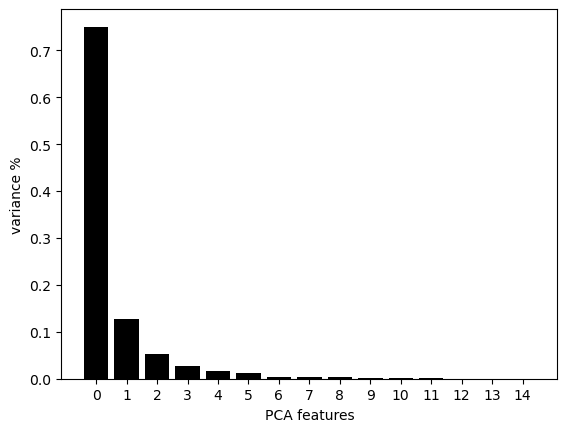

```python
# Do I need to standardize? All my data is in "short tons" so it's the same scale. However, the range does vary widely. I will scale so that
#I don't have some features take over based only on their larger numbers
X_std = StandardScaler().fit_transform(garbage_clean)
# Create a PCA instance: pca
pca = PCA()
principalComponents = pca.fit_transform(X_std)
# Plot the explained variances
features = range(pca.n_components_)
plt.bar(features, pca.explained_variance_ratio_, color='black')
plt.xlabel('PCA features')
plt.ylabel('variance %')
plt.xticks(features)
# Save components to a DataFrame
PCA_components = pd.DataFrame(principalComponents)
```

This shows me that most of the variation in my data can be explained by a single PCA feature. This single PCA feature is a linear combination of my 61 features. This tells me that most of the variation in my data can be accounted for in a single way of combining my features. I think that over all, it tells me that my features are pretty highly correlated. This makes sense. When one category of garbage goes up, its likely that garbage production overall is going up and so other garbage categories are also going up. Plus, this data hasn't been normalized by population, so as the population has increased over the decades, all garbage categories would be increasing. This reminds me that I need to go back and normalize my data based on population. I may want to use this PCA feature 1 as my only feature in a model, since it's a combination of the most variable of my features.

```python
components_matrix = pca.components_

features_vs_pcs = pd.DataFrame(components_matrix, columns=garbage_clean.columns)
features_vs_pcs
```

| Products | Products - Durable Goods - Major Appliances | Products - Durable Goods - Small Appliances | Products - Durable Goods - Furniture and Furnishings | Products - Durable Goods - Carpets and Rugs | Products - Durable Goods - Rubber Tires | Products - Durable Goods - Batteries, Lead-Acid | Products - Durable Goods - Miscellaneous Durables - Selected Consumer Electronics | Products - Durable Goods - Miscellaneous Durables - Other Miscellaneous Durables | Products - Durable Goods - Miscellaneous Durables -- Total | Products - Durable Goods - Total | ... | Products – Containers and Packaging – Paper & Paperboard Pkg -- Total | Products – Containers and Packaging – Plastics Packaging – PET Bottles and Jars | Products – Containers and Packaging – Plastics Packaging – HDPE Natural Bottles | Products – Containers and Packaging – Plastics Packaging – Other Containers | Products – Containers and Packaging – Plastics Packaging – Bags, Sacks, and Wraps -- Subtotal | Products – Containers and Packaging – Plastics Packaging – Other Plastics Packaging | Products – Containers and Packaging – Plastics Packaging -- Total | Products – Containers and Packaging – Wood Packaging | Products – Containers and Packaging – Other Miscellaneous Packaging | Products - Containers and Packaging - Total |
| --- | --- | --- | --- | --- | --- | --- | --- | --- | --- | --- | --- | --- | --- | --- | --- | --- | --- | --- | --- | --- | --- |
| 0 | -0.140018 | -0.132082 | -0.145546 | -0.141979 | -0.144542 | -0.143717 | -0.139869 | -0.145217 | -0.145243 | -0.146016 | ... | -0.144432 | -0.138234 | -0.144271 | -0.142277 | -0.142050 | -0.141762 | -0.146543 | -0.143988 | -0.137534 | -0.145284 |
| 1 | -0.056449 | -0.152288 | -0.057801 | -0.052988 | -0.033094 | -0.004493 | -0.036891 | -0.045062 | -0.052621 | -0.051910 | ... | 0.064823 | -0.101315 | 0.016835 | 0.021137 | 0.033967 | -0.077400 | -0.027298 | -0.005586 | -0.109600 | 0.055234 |
| 2 | 0.125178 | 0.024632 | 0.014402 | -0.049260 | 0.044180 | -0.019128 | -0.006454 | -0.008085 | 0.013590 | 0.012571 | ... | 0.002278 | -0.050717 | -0.099948 | 0.072803 | -0.104786 | -0.003983 | -0.037230 | -0.014365 | -0.035257 | 0.026803 |
| 3 | 0.071661 | -0.079257 | -0.002612 | -0.079880 | 0.021274 | -0.087417 | -0.103309 | 0.039675 | -0.013669 | -0.013329 | ... | -0.007216 | -0.110822 | -0.063823 | -0.054611 | -0.071717 | -0.106445 | -0.058232 | 0.131936 | -0.127966 | -0.011210 |
| 4 | 0.094325 | -0.005701 | -0.051307 | -0.171438 | 0.108707 | -0.072411 | -0.262314 | 0.078330 | 0.052659 | 0.015193 | ... | 0.103736 | 0.036478 | 0.001602 | 0.066288 | 0.142460 | -0.055218 | 0.006971 | 0.085709 | -0.069619 | 0.084186 |
| 5 | -0.025763 | -0.070699 | -0.011388 | -0.047778 | -0.036293 | -0.136386 | 0.059379 | -0.095306 | -0.080347 | -0.040301 | ... | -0.011908 | -0.138315 | 0.065875 | 0.199226 | -0.044385 | 0.109069 | -0.015362 | 0.043055 | -0.055533 | 0.016196 |
| 6 | -0.046381 | -0.078916 | -0.005757 | -0.071542 | 0.016771 | 0.047552 | 0.023947 | 0.101250 | 0.116031 | 0.038148 | ... | -0.037867 | 0.084550 | 0.063920 | -0.180540 | 0.017274 | -0.064404 | -0.028199 | 0.112907 | -0.052780 | 0.008262 |
| 7 | -0.122378 | 0.012843 | -0.034112 | 0.078129 | -0.178667 | 0.236281 | 0.087215 | -0.002029 | 0.019030 | -0.008623 | ... | -0.033760 | -0.012836 | 0.061919 | -0.013457 | -0.049021 | 0.024405 | -0.009315 | -0.063338 | 0.002826 | -0.024413 |
| 8 | 0.022640 | 0.137261 | 0.046946 | 0.073387 | 0.118353 | 0.108589 | -0.019690 | 0.014330 | 0.012310 | 0.046513 | ... | -0.007360 | 0.003772 | 0.043581 | 0.165235 | 0.024784 | 0.103919 | 0.061807 | 0.117087 | 0.108042 | 0.037506 |
| 9 | 0.219900 | -0.079691 | 0.050910 | -0.112679 | 0.023080 | -0.109872 | 0.088368 | 0.079229 | 0.094060 | 0.049840 | ... | 0.094964 | -0.001084 | 0.025345 | -0.108336 | 0.040382 | -0.000821 | -0.005058 | -0.130683 | 0.021356 | 0.023438 |
| 10 | 0.154707 | -0.076855 | 0.016163 | -0.100793 | -0.099642 | -0.198501 | -0.058093 | 0.018133 | -0.004090 | -0.019989 | ... | 0.006020 | -0.017711 | 0.004666 | -0.022372 | 0.105342 | 0.044388 | 0.045698 | -0.048845 | 0.047061 | 0.007799 |
| 11 | 0.026919 | 0.042027 | 0.045435 | 0.084488 | 0.208929 | -0.114714 | 0.164394 | 0.005180 | 0.014831 | 0.044803 | ... | -0.079136 | 0.108830 | 0.117557 | -0.050133 | -0.041718 | -0.029073 | 0.011457 | 0.267014 | -0.017111 | 0.044265 |
| 12 | 0.011486 | 0.101854 | 0.094358 | 0.001433 | -0.120767 | -0.081426 | 0.108633 | -0.116167 | -0.094945 | -0.023020 | ... | 0.002496 | 0.030579 | 0.130923 | 0.018564 | 0.140187 | -0.041114 | 0.018122 | 0.040692 | -0.024210 | 0.006818 |
| 13 | 0.046050 | -0.088862 | -0.039787 | -0.142631 | -0.383118 | 0.121835 | 0.077885 | 0.006121 | 0.005311 | -0.051047 | ... | -0.012688 | -0.098418 | -0.011295 | -0.077341 | 0.200757 | 0.012775 | 0.025399 | 0.214656 | -0.112599 | 0.027669 |
| 14 | -0.620436 | 0.284718 | -0.044595 | 0.104963 | -0.091551 | -0.138046 | -0.156360 | 0.066964 | 0.078615 | -0.083656 | ... | -0.032408 | 0.005066 | 0.186735 | 0.037795 | -0.005322 | -0.094432 | 0.086363 | 0.127437 | -0.182801 | -0.040564 |

15 rows × 61 columns

```python
pd.set_option('display.max_rows', None)
features_vs_pcs.iloc[0]
```

```
Products
Products - Durable Goods - Major Appliances                                                                               -0.140018
Products - Durable Goods - Small Appliances                                                                               -0.132082
Products - Durable Goods - Furniture and Furnishings                                                                      -0.145546
Products - Durable Goods - Carpets and Rugs                                                                               -0.141979
Products - Durable Goods - Rubber Tires                                                                                   -0.144542
Products - Durable Goods - Batteries, Lead-Acid                                                                           -0.143717
Products - Durable Goods - Miscellaneous Durables - Selected Consumer Electronics                                         -0.139869
Products - Durable Goods - Miscellaneous Durables - Other Miscellaneous Durables                                          -0.145217
Products - Durable Goods - Miscellaneous Durables -- Total                                                                -0.145243
Products - Durable Goods - Total                                                                                          -0.146016
Products - Wastes - Total                                                                                                 -0.145878
Other Wastes - Food Waste                                                                                                 -0.130121
Other Wastes - Yard Trimmings                                                                                             -0.139082
Other Wastes - Miscellaneous Inorganic Wastes                                                                             -0.147673
Other Wastes - Total                                                                                                      -0.138948
Total MSW Generated - Weight                                                                                              -0.146650
Products - Nondurable goods – Newspapers/Mechanical Papers                                                                 0.037109
Products – Nondurable goods – Other paper nondurable goods – books                                                         0.137515
Products – Nondurable goods – Other paper nondurable goods – magazines                                                     0.145516
Products -  Nondurable goods – Other paper nondurable goods – office-type papers                                          -0.076232
Products -  Nondurable goods – Other paper nondurable goods – marketing mail                                               0.106982
Products – Nondurable goods – Other paper nondurable goods – other commercial printing                                    -0.004722
Products – Nondurable goods – Other paper nondurable goods – tissue paper and towels                                      -0.145753
Products – Nondurable goods – Other paper nondurable goods – paper plates and cups                                        -0.143911
Products – Nondurable goods – Other paper nondurable goods – other nonpackaging paper                                     -0.083057
Products – Nondurable goods – Other paper nondurable goods – Total                                                        -0.090474
Products – Nondurable goods – Disposable Diapers                                                                          -0.146469
Products – Nondurable goods – Plastic Plates and Cups                                                                     -0.144722
Products – Nondurable goods – Trash Bags                                                                                  -0.144242
Products – Nondurable goods – Clothing and Footwear                                                                       -0.138806
Products – Nondurable goods – Towels, Sheets and Pillowcases                                                              -0.144908
Products – Nondurable goods – Other Miscellaneous Nondurables                                                             -0.141632
Products – Nondurable goods – Total                                                                                       -0.125677
Products – Containers and Packaging – Glass Packaging – Beer and Soft Drink Bottles                                       -0.056898
Products – Containers and Packaging – Glass Packaging – Wine and Liquor Bottles                                           -0.018436
Products – Containers and Packaging – Glass Packaging – Other Bottles and Jars                                             0.104513
Products – Containers and Packaging – Glass Packaging – Total                                                              0.017531
Products – Containers and Packaging – Steel Packaging – Cans                                                               0.142678
Products – Containers and Packaging – Steel Packaging – Other Steel Packaging                                             -0.100331
```

[output cut: 8 more lines]

```
Products – Containers and Packaging – Paper & Paperboard Pkg – Other Paper & Paperboard Pkg- Other Paperboard Packaging    0.124617
Products – Containers and Packaging – Paper & Paperboard Pkg – Other Paper & Paperboard Pkg – Bags and Sacks               0.145254
Products – Containers and Packaging – Paper & Paperboard Pkg – Other Paper & Paperboard Pkg – Other Paper Packaging        0.090273
Products – Containers and Packaging – Paper & Paperboard Pkg – Other Paper & Paperboard Pkg -- Subtotal                   -0.055129
Products – Containers and Packaging – Paper & Paperboard Pkg -- Total                                                     -0.144432
Products – Containers and Packaging – Plastics Packaging – PET Bottles and Jars                                           -0.138234
Products – Containers and Packaging – Plastics Packaging – HDPE Natural Bottles                                           -0.144271
Products – Containers and Packaging – Plastics Packaging – Other Containers                                               -0.142277
Products – Containers and Packaging – Plastics Packaging – Bags, Sacks, and Wraps -- Subtotal                             -0.142050
Products – Containers and Packaging – Plastics Packaging – Other Plastics Packaging                                       -0.141762
Products – Containers and Packaging – Plastics Packaging -- Total                                                         -0.146543
Products – Containers and Packaging – Wood Packaging                                                                      -0.143988
Products – Containers and Packaging – Other Miscellaneous Packaging                                                       -0.137534
Products - Containers and Packaging - Total                                                                               -0.145284
Name: 0, dtype: float64
```

There don't seem to be any features that have a much higher scalar weight than all the others. It seems relatively even across the board, meaning one feature didn't dominate. There are a few with much smaller coefficients (i.e. 'Products – Containers and Packaging – Glass Packaging – Total' or 'Products – Nondurable goods – Other paper nondurable goods – other commercial printing') but there are a large number of these features with very similar absolute valued coefficients.

##### Will PCA look different on my population normalized data?

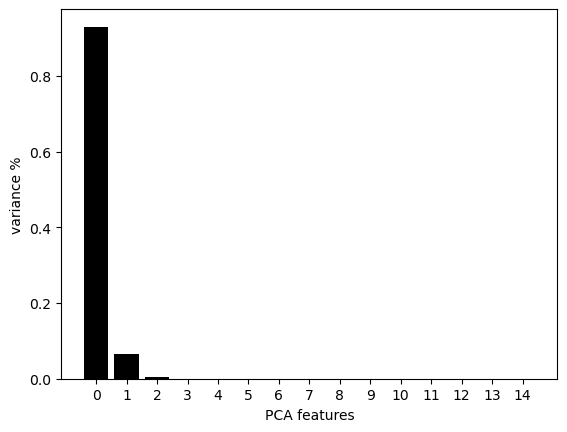

```python
# Create a PCA instance
pca = PCA()
principalComponents = pca.fit_transform(garbage_per_capita)
# Plot the explained variances
features = range(pca.n_components_)
plt.bar(features, pca.explained_variance_ratio_, color='black')
plt.xlabel('PCA features')
plt.ylabel('variance %')
plt.xticks(features)
# Save components to a DataFrame
PCA_components2 = pd.DataFrame(principalComponents)
```

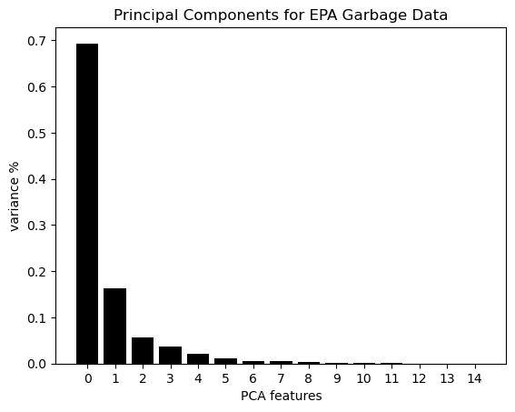

```python
# Do I need to standardize? All my data is in "short tons" so it's the same scale. However, the range does vary widely. I will scale so that
#I don't have some features take over based only on their larger numbers
X_std = StandardScaler().fit_transform(garbage_per_capita.iloc[:,:-2])
# Create a PCA instance: pca
pca = PCA()
principalComponents = pca.fit_transform(X_std)
# Plot the explained variances
features = range(pca.n_components_)
plt.bar(features, pca.explained_variance_ratio_, color='black')
plt.xlabel('PCA features')
plt.ylabel('variance %')
plt.xticks(features)
plt.title("Principal Components for EPA Garbage Data")
plt.savefig("PCAChart.png")
plt.show()
# Save components to a DataFrame
PCA_components = pd.DataFrame(principalComponents)
```

It appears that this (first normalizing by population size, then scaling) better represents the variance in my data. I now have two pca features that together represent between 85 to 90% of the variance in my data. I could use these two features in a model.

```python
components_matrix = pca.components_

features_vs_pcs = pd.DataFrame(components_matrix, columns=garbage_clean.columns)
features_vs_pcs.iloc[0]
```

```
Products
Products - Durable Goods - Major Appliances                                                                               -0.129136
Products - Durable Goods - Small Appliances                                                                               -0.127680
Products - Durable Goods - Furniture and Furnishings                                                                      -0.151769
Products - Durable Goods - Carpets and Rugs                                                                               -0.146048
Products - Durable Goods - Rubber Tires                                                                                   -0.149064
Products - Durable Goods - Batteries, Lead-Acid                                                                           -0.144624
Products - Durable Goods - Miscellaneous Durables - Selected Consumer Electronics                                         -0.140440
Products - Durable Goods - Miscellaneous Durables - Other Miscellaneous Durables                                          -0.151081
Products - Durable Goods - Miscellaneous Durables -- Total                                                                -0.151024
Products - Durable Goods - Total                                                                                          -0.152571
Products - Wastes - Total                                                                                                 -0.138142
Other Wastes - Food Waste                                                                                                 -0.124990
Other Wastes - Yard Trimmings                                                                                              0.050504
Other Wastes - Miscellaneous Inorganic Wastes                                                                             -0.150677
Other Wastes - Total                                                                                                      -0.123073
Total MSW Generated - Weight                                                                                              -0.143423
Products - Nondurable goods – Newspapers/Mechanical Papers                                                                 0.095489
Products – Nondurable goods – Other paper nondurable goods – books                                                         0.151081
Products – Nondurable goods – Other paper nondurable goods – magazines                                                     0.152243
Products -  Nondurable goods – Other paper nondurable goods – office-type papers                                          -0.026830
Products -  Nondurable goods – Other paper nondurable goods – marketing mail                                               0.146346
Products – Nondurable goods – Other paper nondurable goods – other commercial printing                                     0.022368
Products – Nondurable goods – Other paper nondurable goods – tissue paper and towels                                      -0.127409
Products – Nondurable goods – Other paper nondurable goods – paper plates and cups                                        -0.147643
Products – Nondurable goods – Other paper nondurable goods – other nonpackaging paper                                      0.119453
Products – Nondurable goods – Other paper nondurable goods – Total                                                        -0.027369
Products – Nondurable goods – Disposable Diapers                                                                          -0.148903
Products – Nondurable goods – Plastic Plates and Cups                                                                     -0.148686
Products – Nondurable goods – Trash Bags                                                                                  -0.142137
Products – Nondurable goods – Clothing and Footwear                                                                       -0.143152
Products – Nondurable goods – Towels, Sheets and Pillowcases                                                              -0.151518
Products – Nondurable goods – Other Miscellaneous Nondurables                                                             -0.140875
Products – Nondurable goods – Total                                                                                       -0.084290
Products – Containers and Packaging – Glass Packaging – Beer and Soft Drink Bottles                                        0.032648
Products – Containers and Packaging – Glass Packaging – Wine and Liquor Bottles                                            0.099250
Products – Containers and Packaging – Glass Packaging – Other Bottles and Jars                                             0.139135
Products – Containers and Packaging – Glass Packaging – Total                                                              0.106410
Products – Containers and Packaging – Steel Packaging – Cans                                                               0.151842
Products – Containers and Packaging – Steel Packaging – Other Steel Packaging                                             -0.034921
```

[output cut: 8 more lines]

```
Products – Containers and Packaging – Paper & Paperboard Pkg – Other Paper & Paperboard Pkg- Other Paperboard Packaging    0.133913
Products – Containers and Packaging – Paper & Paperboard Pkg – Other Paper & Paperboard Pkg – Bags and Sacks               0.152085
Products – Containers and Packaging – Paper & Paperboard Pkg – Other Paper & Paperboard Pkg – Other Paper Packaging        0.124845
Products – Containers and Packaging – Paper & Paperboard Pkg – Other Paper & Paperboard Pkg -- Subtotal                    0.139953
Products – Containers and Packaging – Paper & Paperboard Pkg -- Total                                                     -0.119715
Products – Containers and Packaging – Plastics Packaging – PET Bottles and Jars                                           -0.140153
Products – Containers and Packaging – Plastics Packaging – HDPE Natural Bottles                                           -0.145716
Products – Containers and Packaging – Plastics Packaging – Other Containers                                               -0.132391
Products – Containers and Packaging – Plastics Packaging – Bags, Sacks, and Wraps -- Subtotal                             -0.141709
Products – Containers and Packaging – Plastics Packaging – Other Plastics Packaging                                       -0.145564
Products – Containers and Packaging – Plastics Packaging -- Total                                                         -0.152452
Products – Containers and Packaging – Wood Packaging                                                                      -0.145783
Products – Containers and Packaging – Other Miscellaneous Packaging                                                       -0.130377
Products - Containers and Packaging - Total                                                                               -0.120935
Name: 0, dtype: float64
```

For feature selection, in this case PCA doesn't seem to be as helpful. It could help me drop out features with coefficients close to zero, but overall that's a pretty small number. The value of PCA in this case may be in the feature engineering. It may be better to take my two new PCA-derived features to run models.

#### PCA for Feature Engineering

I'm going to use the first 2 principle components as derived features to try to predict 2 year ahead unemployment rate.

```
RMSE:  1.1429614859928308
```

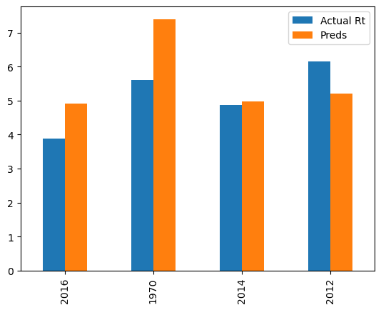

```python
X = PCA_components.loc[:,:1]#only want to use the first two principle components
y = garbage_per_capita['UnemploymtRtShifted2']
X_train, X_test, y_train, y_test = train_test_split(X,y)
LRModel = LinearRegression()
LRModel.fit(X_train, y_train)
preds = LRModel.predict(X_test)
print("RMSE: ", np.sqrt(mean_squared_error(y_test, preds)))
predDF = pd.DataFrame({'Actual Rt': y_test, 'Preds': preds})
predDF.plot.bar()
```

Try to predict unemployment rate 1 year ahead:

```
RMSE:  1.7787054784170582
```

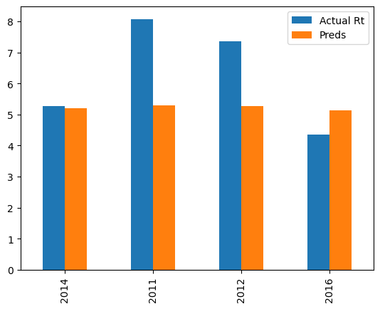

```python
X = PCA_components.loc[:,:1]#only want to use the first two principle components
y = garbage_per_capita['UnemploymtRtShifted1']
X_train, X_test, y_train, y_test = train_test_split(X,y)
LRModel = LinearRegression()
LRModel.fit(X_train, y_train)
preds = LRModel.predict(X_test)
from sklearn.metrics import mean_squared_error
print("RMSE: ", np.sqrt(mean_squared_error(y_test, preds)))
predDF = pd.DataFrame({'Actual Rt': y_test, 'Preds': preds})
predDF.plot.bar()
```

Try to predict the change in unemployment rate coming on 1 year:

```python
unemployment_diff = unemployment['UnemploymentRate'].diff()
unemployment['Rate_Change'] = unemployment_diff.apply(lambda x: 1 if x > 0 else 0)
unemployment.head()
```

| Year | UnemploymentRate | Rate_Change |
| --- | --- | --- |
| 1960 | 5.541667 | 0 |
| 1961 | 6.691667 | 1 |
| 1962 | 5.566667 | 0 |
| 1963 | 5.641667 | 1 |
| 1964 | 5.158333 | 0 |

```python
unempChangeShift1 = unemployment['Rate_Change'].shift(-1)
unempChangeShift1 = pd.DataFrame({'UnempChangeShift1': unempChangeShift1})
unempChangeShift1.head()
```

| Year | UnempChangeShift1 |
| --- | --- |
| 1960 | 1.0 |
| 1961 | 0.0 |
| 1962 | 1.0 |
| 1963 | 0.0 |
| 1964 | 0.0 |

```python
#Add my shifted rate change indicator column to my garbage data
garbage_per_capita = garbage_per_capita.merge(unempChangeShift1, how='left', left_index = True, right_index=True)
```

```python
#Should use logisitic regression since trying to classify, not predict a real value
X = PCA_components.loc[:,:1]#only want to use the first two principle components
y = garbage_per_capita['UnempChangeShift1']
X_train, X_test, y_train, y_test = train_test_split(X, y)
LogReg = LogisticRegression()
LogReg.fit(X_train, y_train)
preds = LogReg.predict(X_test)

print("F1: ", f1_score(y_test, preds))
print("Accuracy :", accuracy_score(y_test, preds))
print(confusion_matrix(y_test, preds))
pd.DataFrame({"Actual":y_test, "Preds":preds})
```

```
F1:  0.0
Accuracy : 0.75
[[3 0]
 [1 0]]
```

|  | Actual | Preds |
| --- | --- | --- |
| 2010 | 0.0 | 0.0 |
| 2015 | 0.0 | 0.0 |
| 2000 | 1.0 | 0.0 |
| 2011 | 0.0 | 0.0 |

It looks as though this model only learned to predict 0. Let me test by running it on all the data.

```python
#Should use logisitic regression since trying to classify, not predict a real value
X = PCA_components.loc[:,:1]#only want to use the first two principle components (in first two columns)
y = garbage_per_capita['UnempChangeShift1']
LogReg = LogisticRegression()
LogReg.fit(X, y)
preds = LogReg.predict(X)

print("F1: ", f1_score(y, preds))
print("Accuracy :", accuracy_score(y, preds))
print(confusion_matrix(y, preds))
pd.DataFrame({"Actual":y, "Preds":preds})
```

```
F1:  1.0
Accuracy : 1.0
[[10  0]
 [ 0  5]]
```

|  | Actual | Preds |
| --- | --- | --- |
| 1960 | 1.0 | 1.0 |
| 1970 | 1.0 | 1.0 |
| 1980 | 1.0 | 1.0 |
| 1990 | 1.0 | 1.0 |
| 2000 | 1.0 | 1.0 |
| 2005 | 0.0 | 0.0 |
| 2010 | 0.0 | 0.0 |
| 2011 | 0.0 | 0.0 |
| 2012 | 0.0 | 0.0 |
| 2013 | 0.0 | 0.0 |
| 2014 | 0.0 | 0.0 |
| 2015 | 0.0 | 0.0 |
| 2016 | 0.0 | 0.0 |
| 2017 | 0.0 | 0.0 |
| 2018 | 0.0 | 0.0 |

This is really makes me wish I had more data. The model can learn to predict 1 or 0, but is it more a matter of "memorizing" the nuance of this few datapoints or is there something in the data that could be helpful? We could really only know if we had sufficient data in which to test this.

#### PCA for Feature Reduction and Visualization

We've explored PCA for feature selection and feature engineering. Another thing it can be helpful for is feature reduction for visualization purposes. Let me try that.

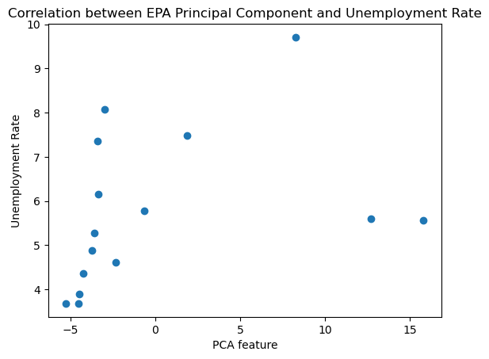

```
Correlation:  0.35950303863940103
```

```python
garbageIndex = garbage_per_capita.index
df = pd.DataFrame(PCA_components.loc[:,0])
df = df.set_index(garbageIndex)
PCACorr = pd.merge(df, pd.Series(garbage_per_capita['UnemploymtRtShifted2']), how='left', left_index = True, right_index=True)
PCACorr
plt.scatter(PCACorr[0], PCACorr['UnemploymtRtShifted2'])
plt.xlabel('PCA feature')
plt.ylabel('Unemployment Rate')
plt.title("Correlation between EPA Principal Component and Unemployment Rate")
plt.savefig("PCACorr1.png")
plt.show()
print('Correlation: ', PCACorr[0].corr(PCACorr['UnemploymtRtShifted2']))
```

I am officially a PCA fan. Being able to visualize this gives so much instantanous information that the single number doesn't convey. The correlation between my PCA feature and the 2 year unemployment shift is relatively low, but the visualization shows a definite positive correlation. It highlights that there are two outliers that aren't fitting the pattern. What would my correlation be if I excluded these?

```
Correlation:  0.7788626546201485
```

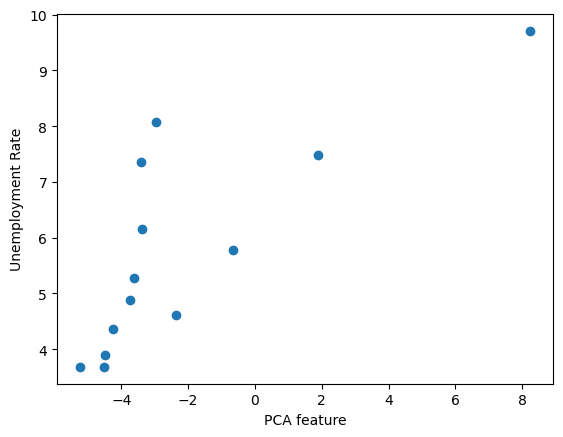

```python
PCACorr = PCACorr.iloc[2:]
plt.scatter(PCACorr[0], PCACorr['UnemploymtRtShifted2'])
plt.xlabel('PCA feature')
plt.ylabel('Unemployment Rate')
#plt.xticks(features)
print('Correlation: ', PCACorr[0].corr(PCACorr['UnemploymtRtShifted2']))
```

Excluding the outliers showed an increased correlation. The graph makes me think there is a good chance, with more complete garbage data, I would be able to do some effective predicting.

What does my PCA feature look like plotted with my future unemployment rate by 1 year?

```
Correlation:  0.29596643960348307
```

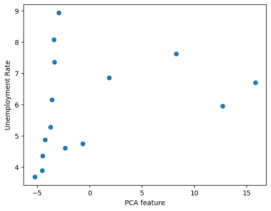

```python
PCACorr = pd.merge(df, pd.Series(garbage_per_capita['UnemploymtRtShifted1']), how='left', left_index = True, right_index=True)
plt.scatter(PCACorr[0], PCACorr['UnemploymtRtShifted1'])
plt.xlabel('PCA feature')
plt.ylabel('Unemployment Rate')
#plt.xticks(features)
print('Correlation: ', PCACorr[0].corr(PCACorr['UnemploymtRtShifted1']))
```

This looks less correlated than with the rate 2 years out. What if I remove the outliers?

```
Correlation:  0.3115199511903109
```

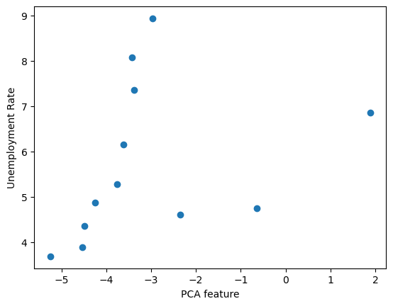

```python
PCACorr = PCACorr[PCACorr[0] < 5]
plt.scatter(PCACorr[0], PCACorr['UnemploymtRtShifted1'])
plt.xlabel('PCA feature')
plt.ylabel('Unemployment Rate')
#plt.xticks(features)
print('Correlation: ', PCACorr[0].corr(PCACorr['UnemploymtRtShifted1']))
```

I'm surprised that the 2 year out unemployment rate showed a higher correlation than the 1 year out unemployment rate (I would assume that the closer to the event, the more likely people are to be modifying their behavior). The positive correlation I see between these two, however, still gives me hope that a full set of garbage data could, indeed be predictive of future economic trends.

### Analysis 2: Linear Regression

I'm going to see if there's any type of linear relationship I can discover between my garbage data and my unemployment numbers. I really don't have a large enough dataset (enough samples) to be able to make any conjectures from this data to a population, but in the interest of investigating my data, I will check.

```python
y = garbage_per_capita['UnemploymtRtShifted2']
X = garbage_per_capita.drop(['UnemploymtRtShifted1', 'UnemploymtRtShifted2'], axis=1)
X_train, X_test, y_train, y_test = train_test_split(X,y)
LRModel = LinearRegression()
LRModel.fit(X_train, y_train)
preds = LRModel.predict(X_test)
from sklearn.metrics import mean_squared_error
print("RMSE: ", np.sqrt(mean_squared_error(y_test, preds)))
```

```
RMSE:  6.911351075237405
```

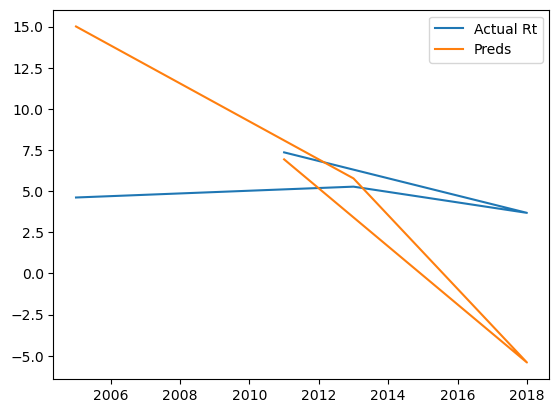

```python
predDF = pd.DataFrame({'Actual Rt': y_test, 'Preds': preds})
predDF.plot.line()
```

```python
#Because this is so small, try running with all samples and see if it tells me anything about my data:
y = garbage_per_capita['UnemploymtRtShifted2']
X = garbage_per_capita.drop(['UnemploymtRtShifted1', 'UnemploymtRtShifted2', 'UnempChangeShift1'], axis=1)
LRModel = LinearRegression()
LRModel.fit(X, y)
preds = LRModel.predict(X)
print("RMSE: ", np.sqrt(mean_squared_error(y, preds)))
```

```
RMSE:  2.2517556413403415e-14
```

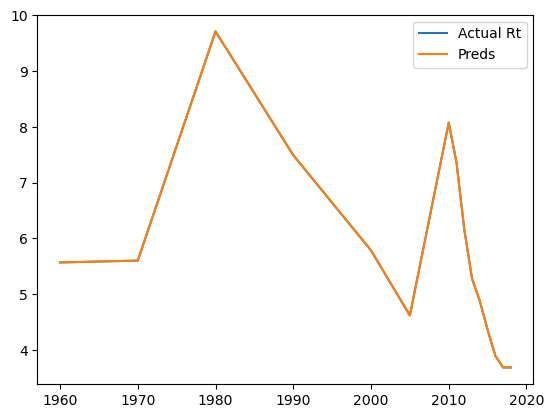

```python
predDF = pd.DataFrame({'Actual Rt': y, 'Preds': preds})
predDF.plot.line()
```

This is interesting. My model is able to create a linear equation using weights for my features to exactly map to the unemployment rate for these 15 years. This doesn't seem likely. Unless my line (since its in R61, it's some sort of multidimensional plane) isn't flat (or maybe straight? I'm not sure what term to use in R61, but it shouldn't be able to bend to accomodate the ys). But since this is a linear model, I thought it had to be straight or flat. I must be not understanding how this works. If I had run the data from our previous Linear Regression assignment through a linear regression model (this time with all the data, no test split out), could it perfectly predict every y value? I know I would expect overfitting, but perfect fitting? All I'm doing is picturing the 4 points my linear algebra teacher gave us when we were learning how to use projection to do Least Squares. In R2, a random 4 points are not likely to all be along a single line. How likely is it that in R61, 15 points are along a single plane?

From a ML model point of view, we can see that with such a small dataset the model is essentially able to "memorize" the variablility of the data (again, how does it do this within the constraints of a linear system?). I wasn't really trying to run this as a ML model (or I wouldn't run it on the entire dataset). I was wondering if this would show me something about my data. I think it just showed me that I don't understand Linear Regression models like I need to.

I went back to the the assignment where we ran linear regression on airline data. In that example, we had 12 features and 1,928,371 samples. I was not able to get a linear regression model to memorize the data. I then only used 15 and then ten of my samples and it still wasn't able to memorize the data (perfectly fit the ys). I'm thinking this has do to with my very large number of features. I'd really like to understand this more.

I don't think I can derive much meaning from my coefficients in this situation, but I want to test this. If I take the coefficients with the largest magnitude and then check their correlation with my y, will it be higher (in absolute value terms) than my other columns?

```python
LRModelWeights = pd.DataFrame({'Column': garbage_per_capita.columns[:-3], 'Weight': LRModel.coef_})
LRModelWeights
```

|  | Column | Weight |
| --- | --- | --- |
| 0 | Products - Durable Goods - Major Appliances | -107.730668 |
| 1 | Products - Durable Goods - Small Appliances | 17.392968 |
| 2 | Products - Durable Goods - Furniture and Furnishings | -63.904083 |
| 3 | Products - Durable Goods - Carpets and Rugs | 53.000147 |
| 4 | Products - Durable Goods - Rubber Tires | -47.674463 |
| 5 | Products - Durable Goods - Batteries, Lead-Acid | 127.232294 |
| 6 | Products - Durable Goods - Miscellaneous Durables - Selected Consumer Electronics | -119.778873 |
| 7 | Products - Durable Goods - Miscellaneous Durables - Other Miscellaneous Durables | 97.391861 |
| 8 | Products - Durable Goods - Miscellaneous Durables -- Total | -51.369620 |
| 9 | Products - Durable Goods - Total | -81.180892 |
| 10 | Products - Wastes - Total | 9.288183 |
| 11 | Other Wastes - Food Waste | 35.240940 |
| 12 | Other Wastes - Yard Trimmings | -49.841868 |
| 13 | Other Wastes - Miscellaneous Inorganic Wastes | -0.973535 |
| 14 | Other Wastes - Total | -15.725048 |
| 15 | Total MSW Generated - Weight | -17.051194 |
| 16 | Products - Nondurable goods – Newspapers/Mechanical Papers | 116.679577 |
| 17 | Products – Nondurable goods – Other paper nondurable goods – books | 13.201312 |
| 18 | Products – Nondurable goods – Other paper nondurable goods – magazines | -28.540169 |
| 19 | Products - Nondurable goods – Other paper nondurable goods – office-type papers | 108.377603 |
| 20 | Products - Nondurable goods – Other paper nondurable goods – marketing mail | -60.435204 |
| 21 | Products – Nondurable goods – Other paper nondurable goods – other commercial printing | -166.427472 |
| 22 | Products – Nondurable goods – Other paper nondurable goods – tissue paper and towels | -39.796675 |
| 23 | Products – Nondurable goods – Other paper nondurable goods – paper plates and cups | 1.103783 |
| 24 | Products – Nondurable goods – Other paper nondurable goods – other nonpackaging paper | -5.645037 |
| 25 | Products – Nondurable goods – Other paper nondurable goods – Total | -74.248008 |
| 26 | Products – Nondurable goods – Disposable Diapers | 36.765359 |
| 27 | Products – Nondurable goods – Plastic Plates and Cups | -13.544913 |
| 28 | Products – Nondurable goods – Trash Bags | 56.439279 |
| 29 | Products – Nondurable goods – Clothing and Footwear | -254.542451 |
| 30 | Products – Nondurable goods – Towels, Sheets and Pillowcases | 80.190259 |
| 31 | Products – Nondurable goods – Other Miscellaneous Nondurables | 68.361684 |
| 32 | Products – Nondurable goods – Total | -34.232828 |
| 33 | Products – Containers and Packaging – Glass Packaging – Beer and Soft Drink Bottles | 80.734111 |
| 34 | Products – Containers and Packaging – Glass Packaging – Wine and Liquor Bottles | 5.373182 |
| 35 | Products – Containers and Packaging – Glass Packaging – Other Bottles and Jars | -154.930927 |
| 36 | Products – Containers and Packaging – Glass Packaging – Total | -68.837278 |
| 37 | Products – Containers and Packaging – Steel Packaging – Cans | 40.151128 |
| 38 | Products – Containers and Packaging – Steel Packaging – Other Steel Packaging | -34.500030 |
| 39 | Products – Containers and Packaging – Steel Packaging – Total | -19.995801 |
| 40 | Products – Containers and Packaging – Aluminum Packaging – Beer and Soft Drink Cans | 52.232991 |
| 41 | Products – Containers and Packaging – Aluminum Packaging – Other Cans | -26.623348 |
| 42 | Products – Containers and Packaging – Aluminum Packaging – Foil and closures | 33.805007 |
| 43 | Products – Containers and Packaging—Aluminum Packaging – Total | 62.823728 |
| 44 | Products – Containers and Packaging – Paper & Paperboard Pkg – Corrugated Boxes | -47.276714 |
| 45 | Products – Containers and Packaging – Paper & Paperboard Pkg – Other Paper & Paperboard Pkg-Gable Top/Aseptic Cartons | -12.584170 |
| 46 | Products – Containers and Packaging – Paper & Paperboard Pkg – Other Paper & Paperboard Pkg- Folding Cartons | 39.290181 |
| 47 | Products – Containers and Packaging – Paper & Paperboard Pkg – Other Paper & Paperboard Pkg- Other Paperboard Packaging | -125.327803 |
| 48 | Products – Containers and Packaging – Paper & Paperboard Pkg – Other Paper & Paperboard Pkg – Bags and Sacks | 54.295929 |
| 49 | Products – Containers and Packaging – Paper & Paperboard Pkg – Other Paper & Paperboard Pkg – Other Paper Packaging | -196.551405 |
| 50 | Products – Containers and Packaging – Paper & Paperboard Pkg – Other Paper & Paperboard Pkg -- Subtotal | -11.307172 |
| 51 | Products – Containers and Packaging – Paper & Paperboard Pkg -- Total | -58.421615 |
| 52 | Products – Containers and Packaging – Plastics Packaging – PET Bottles and Jars | -52.097675 |
| 53 | Products – Containers and Packaging – Plastics Packaging – HDPE Natural Bottles | 3.655687 |
| 54 | Products – Containers and Packaging – Plastics Packaging – Other Containers | 62.335741 |
| 55 | Products – Containers and Packaging – Plastics Packaging – Bags, Sacks, and Wraps -- Subtotal | -7.051181 |
| 56 | Products – Containers and Packaging – Plastics Packaging – Other Plastics Packaging | 51.283466 |
| 57 | Products – Containers and Packaging – Plastics Packaging -- Total | 99.352739 |
| 58 | Products – Containers and Packaging – Wood Packaging | 102.060847 |
| 59 | Products – Containers and Packaging – Other Miscellaneous Packaging | 1.847781 |
| 60 | Products - Containers and Packaging - Total | 118.945809 |

```python
#Create a df of the largest (absolute value) weights and check correlation
WeightyColumns = LRModelWeights['Column'][(LRModelWeights['Weight'] > 100) | (LRModelWeights['Weight'] < -100)]
#Check correlations
correlations = []
for column in WeightyColumns:
    correlation = garbage_per_capita['UnemploymtRtShifted2'].corr(garbage_per_capita[column])
    correlations.append((column, correlation))

correlation_df = pd.DataFrame(correlations, columns=['Column', 'Correlation'])
correlation_df
```

|  | Column | Correlation |
| --- | --- | --- |
| 0 | Products - Durable Goods - Major Appliances | -0.407025 |
| 1 | Products - Durable Goods - Batteries, Lead-Acid | -0.152303 |
| 2 | Products - Durable Goods - Miscellaneous Durables - Selected Consumer Electronics | -0.133894 |
| 3 | Products - Nondurable goods – Newspapers/Mechanical Papers | 0.601414 |
| 4 | Products - Nondurable goods – Other paper nondurable goods – office-type papers | 0.373443 |
| 5 | Products – Nondurable goods – Other paper nondurable goods – other commercial printing | 0.231315 |
| 6 | Products – Nondurable goods – Clothing and Footwear | -0.580963 |
| 7 | Products – Containers and Packaging – Glass Packaging – Other Bottles and Jars | 0.337643 |
| 8 | Products – Containers and Packaging – Paper & Paperboard Pkg – Other Paper & Paperboard Pkg- Other Paperboard Packaging | -0.010950 |
| 9 | Products – Containers and Packaging – Paper & Paperboard Pkg – Other Paper & Paperboard Pkg – Other Paper Packaging | -0.067601 |
| 10 | Products – Containers and Packaging – Wood Packaging | -0.340880 |
| 11 | Products - Containers and Packaging - Total | -0.085163 |

There is not a particularly high correlation between any of the "weighty" columns (the columns with the larger coefficients in the regression equation) and the future unemployment rate. The majority of these correlations, even though small, are negative which is what I would intuitively guess: garbage amounts drop when unemployment goes up as in when times are tight, people throw less away. The largest non-negative correlation is for newspapers. It's interesting to consider that when the economy is struggling (or beginning to struggle) people continue (or perhaps start to) subscribe to newspapers. If we had more data to support this, I might suppose that bad economic news leads people to follow the news more closely.

Now, are these more significant correlations than my "non-weighty" columns?

```python
correlation_df
```

|  | Column | Correlation |
| --- | --- | --- |
| 0 | Products - Durable Goods - Major Appliances | -0.407025 |
| 1 | Products - Durable Goods - Batteries, Lead-Acid | -0.152303 |
| 2 | Products - Durable Goods - Miscellaneous Durables - Selected Consumer Electronics | -0.133894 |
| 3 | Products - Nondurable goods – Newspapers/Mechanical Papers | 0.601414 |
| 4 | Products - Nondurable goods – Other paper nondurable goods – office-type papers | 0.373443 |
| 5 | Products – Nondurable goods – Other paper nondurable goods – other commercial printing | 0.231315 |
| 6 | Products – Nondurable goods – Clothing and Footwear | -0.580963 |
| 7 | Products – Containers and Packaging – Glass Packaging – Other Bottles and Jars | 0.337643 |
| 8 | Products – Containers and Packaging – Paper & Paperboard Pkg – Other Paper & Paperboard Pkg- Other Paperboard Packaging | -0.010950 |
| 9 | Products – Containers and Packaging – Paper & Paperboard Pkg – Other Paper & Paperboard Pkg – Other Paper Packaging | -0.067601 |
| 10 | Products – Containers and Packaging – Wood Packaging | -0.340880 |
| 11 | Products - Containers and Packaging - Total | -0.085163 |

```python
FullColumns = pd.Series(garbage_per_capita.columns)
FullColumns = FullColumns.iloc[:-2]
NonWeightyColumns = FullColumns[~FullColumns.isin(WeightyColumns)]
#Check correlations
correlations = []
for column in NonWeightyColumns:
    correlation = garbage_per_capita['UnemploymtRtShifted2'].corr(garbage_per_capita[column])
    correlations.append((column, correlation))

correlation_df2 = pd.DataFrame(correlations, columns=['Column', 'Correlation'])
compareCorr = pd.DataFrame({"Weighty" : [correlation_df['Correlation'].max(), correlation_df['Correlation'].min()], "Non-Weighty" : [correlation_df2['Correlation'].max(), correlation_df2['Correlation'].min()]})
compareCorr
```

|  | Weighty | Non-Weighty |
| --- | --- | --- |
| 0 | 0.601414 | 0.866741 |
| 1 | -0.580963 | -0.571518 |

This shows me that my larger magnitude coefficients from my linear regression model were not indicative of features more correlated with the target value.

Everything above was run trying to predict the unemployment rate two years in advance. Now let's try 1 year.

```python
y = garbage_per_capita['UnemploymtRtShifted1']
X = garbage_per_capita.drop(['UnemploymtRtShifted1', 'UnemploymtRtShifted2', 'UnempChangeShift1'], axis=1)
X_train, X_test, y_train, y_test = train_test_split(X,y)
LRModel = LinearRegression()
LRModel.fit(X_train, y_train)
preds = LRModel.predict(X_test)
print("RMSE: ", np.sqrt(mean_squared_error(y_test, preds)))
```

```
RMSE:  0.7471609017943032
```

```python
garbage_per_capita['UnemploymtRtShifted1'].max() - garbage_per_capita['UnemploymtRtShifted1'].min()
```

```
5.25
```

This RMSE compared to the range of my unemployment rates isn't encouraging as far as a model goes. However, even if I had good results, my dataset is so small, I'm not sure I can make assumptions about its application to the population anyway. I'd like to check correlation between my features and this y value.

```python
FullColumns = pd.Series(garbage_per_capita.columns)
FullColumns = FullColumns.iloc[:-3] #remove the y columns
#Check correlations
correlations = []
for column in FullColumns:
    correlation = garbage_per_capita['UnemploymtRtShifted1'].corr(garbage_per_capita[column])
    correlations.append((column, correlation))

correlation_df3 = pd.DataFrame(correlations, columns=['Column', 'Correlation'])
correlation_df3 = correlation_df3.sort_values(by="Correlation")
corr_highlights = pd.concat([correlation_df3.head(5), correlation_df3.tail(5)])

correlatedColumns = corr_highlights['Column'] #to use later
corr_highlights
```

|  | Column | Correlation |
| --- | --- | --- |
| 11 | Other Wastes - Food Waste | -0.486553 |
| 0 | Products - Durable Goods - Major Appliances | -0.480590 |
| 14 | Other Wastes - Total | -0.443363 |
| 28 | Products – Nondurable goods – Trash Bags | -0.436538 |
| 29 | Products – Nondurable goods – Clothing and Footwear | -0.432354 |
| 34 | Products – Containers and Packaging – Glass Packaging – Wine and Liquor Bottles | 0.277139 |
| 37 | Products – Containers and Packaging – Steel Packaging – Cans | 0.289530 |
| 17 | Products – Nondurable goods – Other paper nondurable goods – books | 0.289755 |
| 24 | Products – Nondurable goods – Other paper nondurable goods – other nonpackaging paper | 0.330714 |
| 16 | Products - Nondurable goods – Newspapers/Mechanical Papers | 0.349588 |

My most correlated feature is Food Waste. This makes sense that when unemployment is headed up, people waste less food. This is correlating the food waste to the unemployment rate of the following year. Could it be predictive? If I relate this back to my original question, "Can garbage predict a recession?" I don't need the food waste (or any other feature) to actually predict the unemployment rate, just the direction its headed. If its headed up, it's an economic downturn, if it's headed down, it's an economic upturn. I explored this a bit in my WA data. I think I'll see if it shows anything here and I'm going to specifically try using the highly correlated features.

```python
print(unempChangeShift1['UnempChangeShift1'].sum())
print(len(unempChangeShift1))
```

```
20.0
60
```

One third of my years are increasing years, two thirds are decreasing. (This will help for baselining).

Check and what how my features are correlated with the CHANGE in unemployment rate

```python
FullColumns = pd.Series(garbage_per_capita.columns)
FullColumns = FullColumns.iloc[:-3] #remove the y columns
#Check correlations
correlations = []
for column in FullColumns:
    correlation = garbage_per_capita['UnempChangeShift1'].corr(garbage_per_capita[column])
    correlations.append((column, correlation))

correlation_df3 = pd.DataFrame(correlations, columns=['Column', 'Correlation'])
correlation_df3 = correlation_df3.sort_values(by="Correlation")
corr_highlights = pd.concat([correlation_df3.head(5), correlation_df3.tail(5)])

correlatedColumns = corr_highlights['Column'] #to use later
corr_highlights
```

|  | Column | Correlation |
| --- | --- | --- |
| 52 | Products – Containers and Packaging – Plastics Packaging – PET Bottles and Jars | -0.942724 |
| 59 | Products – Containers and Packaging – Other Miscellaneous Packaging | -0.939224 |
| 1 | Products - Durable Goods - Small Appliances | -0.924838 |
| 23 | Products – Nondurable goods – Other paper nondurable goods – paper plates and cups | -0.907012 |
| 29 | Products – Nondurable goods – Clothing and Footwear | -0.900196 |
| 24 | Products – Nondurable goods – Other paper nondurable goods – other nonpackaging paper | 0.823154 |
| 37 | Products – Containers and Packaging – Steel Packaging – Cans | 0.827654 |
| 16 | Products - Nondurable goods – Newspapers/Mechanical Papers | 0.836578 |
| 35 | Products – Containers and Packaging – Glass Packaging – Other Bottles and Jars | 0.899021 |
| 50 | Products – Containers and Packaging – Paper & Paperboard Pkg – Other Paper & Paperboard Pkg -- Subtotal | 0.933685 |

```python
correlation_df3
```

|  | Column | Correlation |
| --- | --- | --- |
| 52 | Products – Containers and Packaging – Plastics Packaging – PET Bottles and Jars | -0.942724 |
| 59 | Products – Containers and Packaging – Other Miscellaneous Packaging | -0.939224 |
| 1 | Products - Durable Goods - Small Appliances | -0.924838 |
| 23 | Products – Nondurable goods – Other paper nondurable goods – paper plates and cups | -0.907012 |
| 29 | Products – Nondurable goods – Clothing and Footwear | -0.900196 |
| 8 | Products - Durable Goods - Miscellaneous Durables -- Total | -0.888167 |
| 3 | Products - Durable Goods - Carpets and Rugs | -0.883870 |
| 56 | Products – Containers and Packaging – Plastics Packaging – Other Plastics Packaging | -0.878970 |
| 9 | Products - Durable Goods - Total | -0.873782 |
| 2 | Products - Durable Goods - Furniture and Furnishings | -0.870915 |
| 30 | Products – Nondurable goods – Towels, Sheets and Pillowcases | -0.854766 |
| 7 | Products - Durable Goods - Miscellaneous Durables - Other Miscellaneous Durables | -0.848878 |
| 6 | Products - Durable Goods - Miscellaneous Durables - Selected Consumer Electronics | -0.845821 |
| 57 | Products – Containers and Packaging – Plastics Packaging -- Total | -0.837747 |
| 5 | Products - Durable Goods - Batteries, Lead-Acid | -0.819560 |
| 27 | Products – Nondurable goods – Plastic Plates and Cups | -0.783523 |
| 4 | Products - Durable Goods - Rubber Tires | -0.765836 |
| 28 | Products – Nondurable goods – Trash Bags | -0.753228 |
| 53 | Products – Containers and Packaging – Plastics Packaging – HDPE Natural Bottles | -0.748576 |
| 13 | Other Wastes - Miscellaneous Inorganic Wastes | -0.730163 |
| 26 | Products – Nondurable goods – Disposable Diapers | -0.728501 |
| 11 | Other Wastes - Food Waste | -0.720797 |
| 58 | Products – Containers and Packaging – Wood Packaging | -0.691857 |
| 55 | Products – Containers and Packaging – Plastics Packaging – Bags, Sacks, and Wraps -- Subtotal | -0.686876 |
| 41 | Products – Containers and Packaging – Aluminum Packaging – Other Cans | -0.674376 |
| 0 | Products - Durable Goods - Major Appliances | -0.646423 |
| 14 | Other Wastes - Total | -0.621367 |
| 15 | Total MSW Generated - Weight | -0.607455 |
| 31 | Products – Nondurable goods – Other Miscellaneous Nondurables | -0.584813 |
| 44 | Products – Containers and Packaging – Paper & Paperboard Pkg – Corrugated Boxes | -0.582398 |
| 54 | Products – Containers and Packaging – Plastics Packaging – Other Containers | -0.555855 |
| 10 | Products - Wastes - Total | -0.548794 |
| 22 | Products – Nondurable goods – Other paper nondurable goods – tissue paper and towels | -0.520951 |
| 38 | Products – Containers and Packaging – Steel Packaging – Other Steel Packaging | -0.496213 |
| 60 | Products - Containers and Packaging - Total | -0.381224 |
| 51 | Products – Containers and Packaging – Paper & Paperboard Pkg -- Total | -0.354004 |
| 43 | Products – Containers and Packaging—Aluminum Packaging – Total | -0.348937 |
| 40 | Products – Containers and Packaging – Aluminum Packaging – Beer and Soft Drink Cans | -0.176424 |
| 32 | Products – Nondurable goods – Total | -0.101433 |
| 42 | Products – Containers and Packaging – Aluminum Packaging – Foil and closures | -0.001983 |
| 25 | Products – Nondurable goods – Other paper nondurable goods – Total | 0.253862 |
| 19 | Products - Nondurable goods – Other paper nondurable goods – office-type papers | 0.289140 |
| 33 | Products – Containers and Packaging – Glass Packaging – Beer and Soft Drink Bottles | 0.397882 |
| 21 | Products – Nondurable goods – Other paper nondurable goods – other commercial printing | 0.520135 |
| 49 | Products – Containers and Packaging – Paper & Paperboard Pkg – Other Paper & Paperboard Pkg – Other Paper Packaging | 0.526540 |
| 46 | Products – Containers and Packaging – Paper & Paperboard Pkg – Other Paper & Paperboard Pkg- Folding Cartons | 0.532349 |
| 47 | Products – Containers and Packaging – Paper & Paperboard Pkg – Other Paper & Paperboard Pkg- Other Paperboard Packaging | 0.584225 |
| 12 | Other Wastes - Yard Trimmings | 0.590191 |
| 45 | Products – Containers and Packaging – Paper & Paperboard Pkg – Other Paper & Paperboard Pkg-Gable Top/Aseptic Cartons | 0.760947 |
| 20 | Products - Nondurable goods – Other paper nondurable goods – marketing mail | 0.772959 |
| 34 | Products – Containers and Packaging – Glass Packaging – Wine and Liquor Bottles | 0.773304 |
| 39 | Products – Containers and Packaging – Steel Packaging – Total | 0.782565 |
| 36 | Products – Containers and Packaging – Glass Packaging – Total | 0.799770 |
| 18 | Products – Nondurable goods – Other paper nondurable goods – magazines | 0.802622 |
| 17 | Products – Nondurable goods – Other paper nondurable goods – books | 0.810526 |
| 48 | Products – Containers and Packaging – Paper & Paperboard Pkg – Other Paper & Paperboard Pkg – Bags and Sacks | 0.820338 |
| 24 | Products – Nondurable goods – Other paper nondurable goods – other nonpackaging paper | 0.823154 |
| 37 | Products – Containers and Packaging – Steel Packaging – Cans | 0.827654 |
| 16 | Products - Nondurable goods – Newspapers/Mechanical Papers | 0.836578 |
| 35 | Products – Containers and Packaging – Glass Packaging – Other Bottles and Jars | 0.899021 |
| 50 | Products – Containers and Packaging – Paper & Paperboard Pkg – Other Paper & Paperboard Pkg -- Subtotal | 0.933685 |

I have a lot of highly correlated features (both positive and negative). I would surmise that many of these features that have similar correlation values are highly correlated to each other as well.

```python
pd.set_option('display.max_colwidth', None)
correlatedColumns
```

```
52                            Products – Containers and Packaging – Plastics Packaging – PET Bottles and Jars
59                                        Products – Containers and Packaging – Other Miscellaneous Packaging
1                                                                 Products - Durable Goods - Small Appliances
23                         Products – Nondurable goods – Other paper nondurable goods – paper plates and cups
29                                                        Products – Nondurable goods – Clothing and Footwear
24                      Products – Nondurable goods – Other paper nondurable goods – other nonpackaging paper
37                                               Products – Containers and Packaging – Steel Packaging – Cans
16                                                 Products - Nondurable goods – Newspapers/Mechanical Papers
35                             Products – Containers and Packaging – Glass Packaging – Other Bottles and Jars
50    Products – Containers and Packaging – Paper & Paperboard Pkg – Other Paper & Paperboard Pkg -- Subtotal
Name: Column, dtype: object
```

These are the full names of the columns that were highly correlated with the change in the unemployment rate. The first five are negatively correlated, the last five are positive. For all my tinkering, this may be the first real insight I've found in my data. It's interesting to consider what people throw away more when feeling economic instability versus what they throw away less. It appears people throw away less: plastic bottles, containers, small appliances, paper plates, and clothing. During times of unemployment do people tend to purchase fewer things in bottles? One easy way to cut back is to not buy water in plastic bottles. I would assume they buy less over all which is why containers would be going down. They would not be replacing their small appliances during that time. It's easy to cut paper plates out of the budget by using regular plates when trying to cut back and it's easy to not purchase new clothes, but continue to wear the old ones.

Why would the last five be positively correlated? Paper, Cans, newspapers, glass jars, Other paperboard. I have no conjectures on the paper, but the cans and glass jars could indicate people eating food that has been stored (rather than out in restaurants or fresh food) during times of economic downturn. I already conjectured on the newspapers.

```python
#Save the names correlations as a excel file to import into report
corr_highlights.to_excel('correlation_highlights.xlsx', index=False)
```

How would this little dataset do in trying to predict whether unemployment rates will be rising or falling in the next year? Again, I proceed with caution. My number of samples is too small to really be able to make assumptions about the population, but for research's sake, I'll try it.

```python
y = garbage_per_capita['UnempChangeShift1']
X = garbage_per_capita.iloc[:, :-3]#select all the rows, all columns less the last three
X_train, X_test, y_train, y_test = train_test_split(X, y)
LogReg = LogisticRegression()
LogReg.fit(X_train, y_train)
preds = LogReg.predict(X_test)

print("F1: ", f1_score(y_test, preds))
print("Accuracy :", accuracy_score(y_test, preds))
print(confusion_matrix(y_test, preds))
```

```
F1:  0.0
Accuracy : 0.5
[[2 0]
 [2 0]]
```

```python
predictions = pd.DataFrame({"Ground Truth": y_test, "Preds": preds})
predictions
```

|  | Ground Truth | Preds |
| --- | --- | --- |
| 2005 | 0.0 | 0.0 |
| 1990 | 1.0 | 0.0 |
| 1960 | 1.0 | 0.0 |
| 2018 | 0.0 | 0.0 |

Although its hard to tell with so few data points, its possible the model learned to only predict the main class: 0. I didn't do any class balancing.

```python
y = garbage_per_capita['UnempChangeShift1']
X = garbage_per_capita.iloc[:, :-3]#select all the rows, all columns less the last three
#X_train, X_test, y_train, y_test = train_test_split(X, y)
LogReg = LogisticRegression()
LogReg.fit(X, y)
preds = LogReg.predict(X)
print("F1: ", f1_score(y, preds))
print("Accuracy :", accuracy_score(y, preds))
print(confusion_matrix(y, preds))
predictions = pd.DataFrame({"Ground Truth": y, "Preds": preds})
predictions
```

```
F1:  0.0
Accuracy : 0.6666666666666666
[[10  0]
 [ 5  0]]
```

|  | Ground Truth | Preds |
| --- | --- | --- |
| 1960 | 1.0 | 0.0 |
| 1970 | 1.0 | 0.0 |
| 1980 | 1.0 | 0.0 |
| 1990 | 1.0 | 0.0 |
| 2000 | 1.0 | 0.0 |
| 2005 | 0.0 | 0.0 |
| 2010 | 0.0 | 0.0 |
| 2011 | 0.0 | 0.0 |
| 2012 | 0.0 | 0.0 |
| 2013 | 0.0 | 0.0 |
| 2014 | 0.0 | 0.0 |
| 2015 | 0.0 | 0.0 |
| 2016 | 0.0 | 0.0 |
| 2017 | 0.0 | 0.0 |
| 2018 | 0.0 | 0.0 |

It appears the model only learned to predict the majority class. I'm not really sure it's meaningful to even attempt to run a model on this size of dataset. I think the most I might be able to understand is that I do have quite a number of features that are highly correlated with the movement of the unemployment rate. I think I'll next attempt to impute missing years of data. I'm not really sure if this is a valid thing to do. I'm assuming that the change in garbage per category from one year to the next follows a trend. But, if I'm hypothesizing that people change their discarding behaviors based on financial stability (or instability) then the data is changing beyond what a time trend would be assuming.

### Imputing Data for Missing Years

First add rows for the missing years and interpolate the data.

```python
garbage_full_years = garbage_per_capita.copy().iloc[:,:-3]#don't want to interpolate the y columns
years_range = range(1960, 2019)
garbage_full_years = garbage_full_years.reindex(years_range) #this is adding rows to my df
garbage_full_years.interpolate(method='linear', axis=0, inplace=True)
garbage_full_years.head()
#May I please stop right here and rhapsodize over what this just did? This code is so simple and look at what it did with my data! Coming
#from a database background I am in awe of the tools we now have to work with (and a little intimidated at the gulf between where I am and
#where I want to be in order to be good at using them).
```

|  | Products - Durable Goods - Major Appliances | Products - Durable Goods - Small Appliances | Products - Durable Goods - Furniture and Furnishings | Products - Durable Goods - Carpets and Rugs | Products - Durable Goods - Rubber Tires | Products - Durable Goods - Batteries, Lead-Acid | Products - Durable Goods - Miscellaneous Durables - Selected Consumer Electronics | Products - Durable Goods - Miscellaneous Durables - Other Miscellaneous Durables | Products - Durable Goods - Miscellaneous Durables -- Total | Products - Durable Goods - Total | ... | Products – Containers and Packaging – Paper & Paperboard Pkg -- Total | Products – Containers and Packaging – Plastics Packaging – PET Bottles and Jars | Products – Containers and Packaging – Plastics Packaging – HDPE Natural Bottles | Products – Containers and Packaging – Plastics Packaging – Other Containers | Products – Containers and Packaging – Plastics Packaging – Bags, Sacks, and Wraps -- Subtotal | Products – Containers and Packaging – Plastics Packaging – Other Plastics Packaging | Products – Containers and Packaging – Plastics Packaging -- Total | Products – Containers and Packaging – Wood Packaging | Products – Containers and Packaging – Other Miscellaneous Packaging | Products - Containers and Packaging - Total |
| --- | --- | --- | --- | --- | --- | --- | --- | --- | --- | --- | --- | --- | --- | --- | --- | --- | --- | --- | --- | --- | --- |
| 1960 | 0.009022 | 0.002546 | 0.011900 | 0.002625 | 0.006199 | 0.002626 | 0.002404 | 0.019005 | 0.027785 | 0.054907 | ... | 0.078098 | 0.001439 | 0.000584 | 0.000332 | 0.002988 | 0.000332 | 0.000664 | 0.011070 | 0.000664 | 0.151492 |
| 1961 | 0.009178 | 0.002516 | 0.012090 | 0.002594 | 0.006501 | 0.002763 | 0.002613 | 0.018779 | 0.028396 | 0.056566 | ... | 0.080725 | 0.001422 | 0.000639 | 0.000743 | 0.003277 | 0.000874 | 0.001617 | 0.010972 | 0.000661 | 0.157586 |
| 1962 | 0.009334 | 0.002486 | 0.012280 | 0.002563 | 0.006803 | 0.002901 | 0.002821 | 0.018553 | 0.029007 | 0.058224 | ... | 0.083352 | 0.001405 | 0.000693 | 0.001153 | 0.003566 | 0.001417 | 0.002570 | 0.010875 | 0.000658 | 0.163681 |
| 1963 | 0.009490 | 0.002455 | 0.012471 | 0.002531 | 0.007105 | 0.003038 | 0.003029 | 0.018327 | 0.029618 | 0.059883 | ... | 0.085978 | 0.001388 | 0.000748 | 0.001564 | 0.003856 | 0.001959 | 0.003523 | 0.010777 | 0.000655 | 0.169775 |
| 1964 | 0.009646 | 0.002425 | 0.012661 | 0.002500 | 0.007406 | 0.003175 | 0.003238 | 0.018101 | 0.030229 | 0.061542 | ... | 0.088605 | 0.001371 | 0.000802 | 0.001974 | 0.004145 | 0.002501 | 0.004476 | 0.010680 | 0.000652 | 0.175869 |

5 rows × 61 columns

Adding back in the unemployment values.

```python
garbage_full_years = pd.merge(garbage_full_years, unemploymentShift, how='left', left_index=True, right_index=True)
garbage_full_years = garbage_full_years.merge(unempChangeShift1, how='left', left_index = True, right_index=True)
garbage_full_years.head()
```

|  | Products - Durable Goods - Major Appliances | Products - Durable Goods - Small Appliances | Products - Durable Goods - Furniture and Furnishings | Products - Durable Goods - Carpets and Rugs | Products - Durable Goods - Rubber Tires | Products - Durable Goods - Batteries, Lead-Acid | Products - Durable Goods - Miscellaneous Durables - Selected Consumer Electronics | Products - Durable Goods - Miscellaneous Durables - Other Miscellaneous Durables | Products - Durable Goods - Miscellaneous Durables -- Total | Products - Durable Goods - Total | ... | Products – Containers and Packaging – Plastics Packaging – Other Containers | Products – Containers and Packaging – Plastics Packaging – Bags, Sacks, and Wraps -- Subtotal | Products – Containers and Packaging – Plastics Packaging – Other Plastics Packaging | Products – Containers and Packaging – Plastics Packaging -- Total | Products – Containers and Packaging – Wood Packaging | Products – Containers and Packaging – Other Miscellaneous Packaging | Products - Containers and Packaging - Total | UnemploymtRtShifted1 | UnemploymtRtShifted2 | UnempChangeShift1 |
| --- | --- | --- | --- | --- | --- | --- | --- | --- | --- | --- | --- | --- | --- | --- | --- | --- | --- | --- | --- | --- | --- |
| 1960 | 0.009022 | 0.002546 | 0.011900 | 0.002625 | 0.006199 | 0.002626 | 0.002404 | 0.019005 | 0.027785 | 0.054907 | ... | 0.000332 | 0.002988 | 0.000332 | 0.000664 | 0.011070 | 0.000664 | 0.151492 | 6.691667 | 5.566667 | 1.0 |
| 1961 | 0.009178 | 0.002516 | 0.012090 | 0.002594 | 0.006501 | 0.002763 | 0.002613 | 0.018779 | 0.028396 | 0.056566 | ... | 0.000743 | 0.003277 | 0.000874 | 0.001617 | 0.010972 | 0.000661 | 0.157586 | 5.566667 | 5.641667 | 0.0 |
| 1962 | 0.009334 | 0.002486 | 0.012280 | 0.002563 | 0.006803 | 0.002901 | 0.002821 | 0.018553 | 0.029007 | 0.058224 | ... | 0.001153 | 0.003566 | 0.001417 | 0.002570 | 0.010875 | 0.000658 | 0.163681 | 5.641667 | 5.158333 | 1.0 |
| 1963 | 0.009490 | 0.002455 | 0.012471 | 0.002531 | 0.007105 | 0.003038 | 0.003029 | 0.018327 | 0.029618 | 0.059883 | ... | 0.001564 | 0.003856 | 0.001959 | 0.003523 | 0.010777 | 0.000655 | 0.169775 | 5.158333 | 4.508333 | 0.0 |
| 1964 | 0.009646 | 0.002425 | 0.012661 | 0.002500 | 0.007406 | 0.003175 | 0.003238 | 0.018101 | 0.030229 | 0.061542 | ... | 0.001974 | 0.004145 | 0.002501 | 0.004476 | 0.010680 | 0.000652 | 0.175869 | 4.508333 | 3.791667 | 0.0 |

5 rows × 64 columns

I now have 59 rows of samples. This is still not a large dataset, but I'd like to see if it has any predictive ability.

### Running Models on Imputed Year Dataset

#### Decision Tree

Try predicting the value of Unemployment Rate 2 years out.

```
RMSE:  1.4352183986598872
```

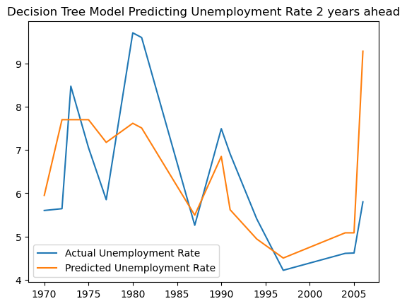

```python
y = garbage_full_years['UnemploymtRtShifted2']
X = garbage_full_years.iloc[:,:-3] #exclude y columns
X_train, X_test, y_train, y_test = train_test_split(X, y, random_state=7)
dtReg = DecisionTreeRegressor()
dtReg.fit(X_train, y_train)
preds = dtReg.predict(X_test)
print('RMSE: ', np.sqrt(mean_squared_error(y_test, preds)))
df = pd.DataFrame({'Actual Unemployment Rate': y_test, 'Predicted Unemployment Rate': preds}).sort_index()
df.plot.line()
plt.title("Decision Tree Model Predicting Unemployment Rate 2 years ahead")
plt.savefig('DTImputedRows.png')
plt.show()
```

The graphs really shows an amazing picture! (And way more information that the metric does). This model may not be able to predict the exact amount that unemployment will spike but from 1980 on, it predicted each spike that would happen. The garbage data was able to predict 2 years ahead of time that unemployment was going to spike.

I manufactured a y value that classifies whether unemployement is rising or falling. How well can a decision tree prediction this classification?

```python
y = garbage_full_years['UnempChangeShift1']
X = garbage_full_years.iloc[:,:-3] #exclude y columns
X_train, X_test, y_train, y_test = train_test_split(X, y)
dtCl = DecisionTreeClassifier()
dtCl.fit(X_train, y_train)
preds = dtCl.predict(X_test)
print('Accuracy: ', accuracy_score(y_test, preds))
print('F1: ', f1_score(y_test, preds))
print(confusion_matrix(y_test, preds))
#df = pd.DataFrame({'Actual': y_test, 'Preds': preds}).sort_index()
```

```
Accuracy:  0.6666666666666666
F1:  0.4444444444444445
[[8 3]
 [2 2]]
```

#### Linear Regression

```
RMSE:  112696434286.96074
```

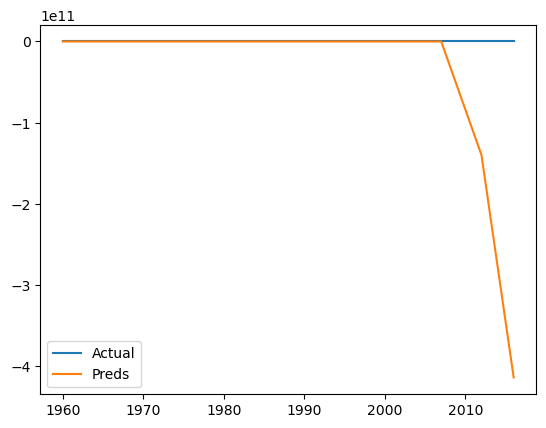

```python
y = garbage_full_years['UnemploymtRtShifted2']
X = garbage_full_years.iloc[:,:-3] #exclude y columns
X_train, X_test, y_train, y_test = train_test_split(X, y)
lr = LinearRegression()
lr.fit(X_train, y_train)
preds = lr.predict(X_test)
print('RMSE: ', np.sqrt(mean_squared_error(y_test, preds)))
df = pd.DataFrame({'Actual': y_test, 'Preds': preds}).sort_index()
df.plot.line()
```

I don't need to worry about scaling my data for Decision Trees, but this shows makes it quite apparent that it is necessary for Linear Regression.

```
RMSE:  1.1049472686453334
```

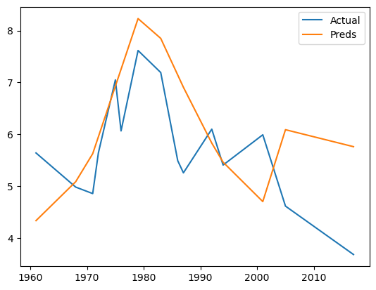

```python
y = garbage_full_years['UnemploymtRtShifted2']
X = StandardScaler().fit_transform(garbage_full_years.iloc[:,:-3])
#X = garbage_full_years.iloc[:,:-3] #exclude y columns
X_train, X_test, y_train, y_test = train_test_split(X, y)
lr = LinearRegression()
lr.fit(X_train, y_train)
preds = lr.predict(X_test)
print('RMSE: ', np.sqrt(mean_squared_error(y_test, preds)))
df = pd.DataFrame({'Actual': y_test, 'Preds': preds}).sort_index()
df.plot.line()
```

This has a lower error rate than the Decision Tree Regressor, but it doesn't predict the spikes in unemployment as well.

#### Logistic Regression

```python
y = garbage_full_years['UnempChangeShift1']
X = StandardScaler().fit_transform(garbage_full_years.iloc[:,:-3])
X_train, X_test, y_train, y_test = train_test_split(X, y, random_state=12)
LogR = LogisticRegression()
LogR.fit(X_train, y_train)
preds = LogR.predict(X_test)
print('Accuracy: ', accuracy_score(y_test, preds))
print('F1: ', f1_score(y_test, preds))
print(confusion_matrix(y_test, preds))
df = pd.DataFrame({'Actual': y_test, 'Preds': preds}).sort_index()
df
```

```
Accuracy:  0.5333333333333333
F1:  0.0
[[8 4]
 [3 0]]
```

|  | Actual | Preds |
| --- | --- | --- |
| 1967 | 0.0 | 0.0 |
| 1968 | 0.0 | 0.0 |
| 1979 | 1.0 | 0.0 |
| 1983 | 0.0 | 0.0 |
| 1984 | 0.0 | 0.0 |
| 1986 | 0.0 | 0.0 |
| 1989 | 1.0 | 0.0 |
| 2001 | 1.0 | 0.0 |
| 2003 | 0.0 | 1.0 |
| 2004 | 0.0 | 1.0 |
| 2005 | 0.0 | 1.0 |
| 2010 | 0.0 | 1.0 |
| 2012 | 0.0 | 0.0 |
| 2014 | 0.0 | 0.0 |
| 2017 | 0.0 | 0.0 |

This is a very ineffectual classifier. I didn't do any class balancing, though. It may be affected by the imbalanced classes.

#### Support Vector Machine

```python
y = garbage_full_years['UnempChangeShift1']
X = StandardScaler().fit_transform(garbage_full_years.iloc[:,:-3])
X_train, X_test, y_train, y_test = train_test_split(X, y, random_state=12)
SVM = SVC()
SVM.fit(X_train, y_train)
preds = SVM.predict(X_test)
print('Accuracy: ', accuracy_score(y_test, preds))
print('F1: ', f1_score(y_test, preds))
print(confusion_matrix(y_test, preds))
df = pd.DataFrame({'Actual': y_test, 'Preds': preds}).sort_index()
df
```

```
Accuracy:  0.6666666666666666
F1:  0.0
[[10  2]
 [ 3  0]]
```

|  | Actual | Preds |
| --- | --- | --- |
| 1967 | 0.0 | 0.0 |
| 1968 | 0.0 | 0.0 |
| 1979 | 1.0 | 0.0 |
| 1983 | 0.0 | 0.0 |
| 1984 | 0.0 | 0.0 |
| 1986 | 0.0 | 0.0 |
| 1989 | 1.0 | 0.0 |
| 2001 | 1.0 | 0.0 |
| 2003 | 0.0 | 0.0 |
| 2004 | 0.0 | 1.0 |
| 2005 | 0.0 | 1.0 |
| 2010 | 0.0 | 0.0 |
| 2012 | 0.0 | 0.0 |
| 2014 | 0.0 | 0.0 |
| 2017 | 0.0 | 0.0 |

This is a good example of needing to look at both the accuracy and the F1 score. The accuracy by itself looks decent. But the F1 shows another story. The high accuracy is because it mostly just predicted the predominant class. Perhaps I should alter my regularization parameter.

```python
y = garbage_full_years['UnempChangeShift1']
X = StandardScaler().fit_transform(garbage_full_years.iloc[:,:-3])
X_train, X_test, y_train, y_test = train_test_split(X, y, random_state=12)
SVM = SVC(C=10)
SVM.fit(X_train, y_train)
preds = SVM.predict(X_test)
print('Accuracy: ', accuracy_score(y_test, preds))
print('F1: ', f1_score(y_test, preds))
print(confusion_matrix(y_test, preds))
df = pd.DataFrame({'Actual': y_test, 'Preds': preds}).sort_index()
df
```

```
Accuracy:  0.5333333333333333
F1:  0.2222222222222222
[[7 5]
 [2 1]]
```

|  | Actual | Preds |
| --- | --- | --- |
| 1967 | 0.0 | 0.0 |
| 1968 | 0.0 | 1.0 |
| 1979 | 1.0 | 0.0 |
| 1983 | 0.0 | 0.0 |
| 1984 | 0.0 | 0.0 |
| 1986 | 0.0 | 0.0 |
| 1989 | 1.0 | 0.0 |
| 2001 | 1.0 | 1.0 |
| 2003 | 0.0 | 1.0 |
| 2004 | 0.0 | 1.0 |
| 2005 | 0.0 | 1.0 |
| 2010 | 0.0 | 1.0 |
| 2012 | 0.0 | 0.0 |
| 2014 | 0.0 | 0.0 |
| 2017 | 0.0 | 0.0 |

### Feature Selection with Imputed Data and Classification Models

#### Classification models with only the highly correlated features.

##### Decision Tree Classifier

```python
y = garbage_full_years['UnempChangeShift1']
X = garbage_full_years[correlatedColumns]
X_train, X_test, y_train, y_test = train_test_split(X, y, random_state=12)
dtCl = DecisionTreeClassifier()
dtCl.fit(X_train, y_train)
preds = dtCl.predict(X_test)
print('Accuracy: ', accuracy_score(y_test, preds))
print('F1: ', f1_score(y_test, preds))
print(confusion_matrix(y_test, preds))
```

```
Accuracy:  0.5333333333333333
F1:  0.36363636363636365
[[6 6]
 [1 2]]
```

This is worse than the Decision Tree Classifier using all the features.

##### Logistic Regression

```python
y = garbage_full_years['UnempChangeShift1']
X = StandardScaler().fit_transform(garbage_full_years[correlatedColumns])
X_train, X_test, y_train, y_test = train_test_split(X, y, random_state=12)
LogR = LogisticRegression()
LogR.fit(X_train, y_train)
preds = LogR.predict(X_test)
print('Accuracy: ', accuracy_score(y_test, preds))
print('F1: ', f1_score(y_test, preds))
print(confusion_matrix(y_test, preds))
df = pd.DataFrame({'Actual': y_test, 'Preds': preds}).sort_index()
df
```

```
Accuracy:  0.5333333333333333
F1:  0.0
[[8 4]
 [3 0]]
```

|  | Actual | Preds |
| --- | --- | --- |
| 1967 | 0.0 | 0.0 |
| 1968 | 0.0 | 0.0 |
| 1979 | 1.0 | 0.0 |
| 1983 | 0.0 | 0.0 |
| 1984 | 0.0 | 0.0 |
| 1986 | 0.0 | 0.0 |
| 1989 | 1.0 | 0.0 |
| 2001 | 1.0 | 0.0 |
| 2003 | 0.0 | 1.0 |
| 2004 | 0.0 | 1.0 |
| 2005 | 0.0 | 1.0 |
| 2010 | 0.0 | 1.0 |
| 2012 | 0.0 | 0.0 |
| 2014 | 0.0 | 0.0 |
| 2017 | 0.0 | 0.0 |

This is the same as how it performed with all the features.

##### Support Vector Machine

```python
y = garbage_full_years['UnempChangeShift1']
X = StandardScaler().fit_transform(garbage_full_years[correlatedColumns])
X_train, X_test, y_train, y_test = train_test_split(X, y, random_state=12)
SVM = SVC(C=10)
SVM.fit(X_train, y_train)
preds = SVM.predict(X_test)
print('Accuracy: ', accuracy_score(y_test, preds))
print('F1: ', f1_score(y_test, preds))
print(confusion_matrix(y_test, preds))
df = pd.DataFrame({'Actual': y_test, 'Preds': preds}).sort_index()
df
```

```
Accuracy:  0.6
F1:  0.25
[[8 4]
 [2 1]]
```

|  | Actual | Preds |
| --- | --- | --- |
| 1967 | 0.0 | 0.0 |
| 1968 | 0.0 | 0.0 |
| 1979 | 1.0 | 0.0 |
| 1983 | 0.0 | 0.0 |
| 1984 | 0.0 | 0.0 |
| 1986 | 0.0 | 0.0 |
| 1989 | 1.0 | 0.0 |
| 2001 | 1.0 | 1.0 |
| 2003 | 0.0 | 1.0 |
| 2004 | 0.0 | 1.0 |
| 2005 | 0.0 | 1.0 |
| 2010 | 0.0 | 1.0 |
| 2012 | 0.0 | 0.0 |
| 2014 | 0.0 | 0.0 |
| 2017 | 0.0 | 0.0 |

This is a slight improvement over the SVM with all the features, but still a poor performing model.

### PCA Features and Decision Trees

I am now curious about bringing the promising things I foung together: an imputed dataset, PCA components as features and a Decision Tree as a model.

Run PCA on imputed dataset:

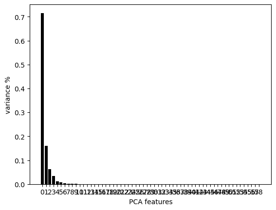

```python
X_std = StandardScaler().fit_transform(garbage_full_years.iloc[:,:-3])
# Create a PCA instance: pca
pca = PCA()
principalComponents = pca.fit_transform(X_std)
# Plot the explained variances
features = range(pca.n_components_)
plt.bar(features, pca.explained_variance_ratio_, color='black')
plt.xlabel('PCA features')
plt.ylabel('variance %')
plt.xticks(features)
# Save components to a DataFrame
PCA_components = pd.DataFrame(principalComponents)
```

What if I use the first 3 principle components as features for a Decision Tree?

```
RMSE:  1.0615611320301044
```

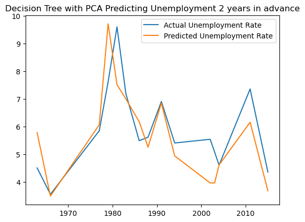

```python
X = PCA_components.iloc[:,:3]
y = garbage_full_years['UnemploymtRtShifted2']
X_train, X_test, y_train, y_test = train_test_split(X, y, random_state=5)
dtReg = DecisionTreeRegressor()
dtReg.fit(X_train, y_train)
preds = dtReg.predict(X_test)
print('RMSE: ', np.sqrt(mean_squared_error(y_test, preds)))
df = pd.DataFrame({'Actual Unemployment Rate': y_test, 'Predicted Unemployment Rate': preds}).sort_index()
df.plot.line()
plt.title('Decision Tree with PCA Predicting Unemployment 2 years in advance')
plt.savefig('DTImputedRowsPCA.png')
plt.show()
```

Does this improve if I use an ensemble approach with my Decision Tree?

```
RMSE:  0.8596805508658661
```

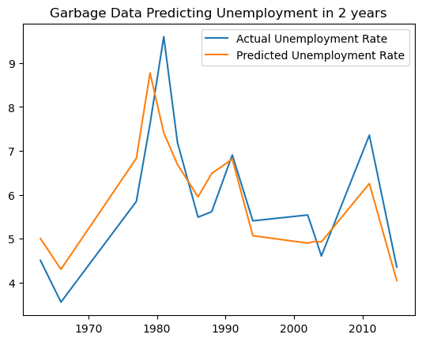

```python
X = PCA_components.iloc[:,:3]
y = garbage_full_years['UnemploymtRtShifted2']
X_train, X_test, y_train, y_test = train_test_split(X, y, random_state=5)
rf = RandomForestRegressor()
rf.fit(X_train, y_train)
preds = rf.predict(X_test)
print('RMSE: ', np.sqrt(mean_squared_error(y_test, preds)))
df = pd.DataFrame({'Actual Unemployment Rate': y_test, 'Predicted Unemployment Rate': preds}).sort_index()
df.plot.line()
plt.title("Garbage Data Predicting Unemployment in 2 years")
plt.savefig('RFImputedRowsPCA.png')
plt.show()
```

This model is on average about a percentage point off, but the graph shows that it actually maps the trend of the unemployment rate changes remarkably well.

Overall, I believe garbage data has the potential to have a number of predictive abilities when it comes to economic values. I've seen evidence of moderate to strong correlation with some of the data. With imputed data, I was able to train some models that could mimic the trend of the unemployment rate. I feel like the data I have to work with is insufficient to make stronger claims, but I believe this area of study warrants further exploration.